# ProyectoFinal_AlejandroDominguezRecio

2022-06-16

## 1 Introducción

Actualmente existen marcadores biomoleculares relacionados con la respuesta de distintos tipos de quimioterápia en cáncer de mama. No obstante la precisión de los marcadores existentes en la selección del tipo quimioterápia es todavía baja. Con el fin de solucionar este problema se han añadido marcadores géneticos asociados a la respuesta de tratamientos específicos de quimioterápia.

El objetivo de este proyecto es obtener un modelo predictivo que determine la respuesta de una combinación quimioterapéutica en cancer de mama.

Se entrenarán distintos modelos predictivos con menos de 10 variables y se evaluarán con distintas métricas.

A su vez se tratarán los distintos problemas propios del conjunto de datos como los valores perdidos, desbalanceo de clases o estandarización de variables.

## 2 Metodología: Datos y algoritmos de clasificación

### 2.1 Dataset

En este proyecto tenemos a disposición un conjunto de **178 observaciones** cada una de ellas con dos conjuntos de características asociados. Tenemos un conjunto de **8 características clínicas patológicas** y otro conjunto de **13516 genes**.

Las variables del conjunto clínico patológico se encuentran en formato categórico y numérico ordinal. El conjuto de variables numéricos ordinales identifican distintos tipos de categorías en la variable asociada. En el conjunto de 13516 genes el total se encuentra en formato numérico continuo.

Por la características de algunos de los algoritmos aplicados en procesamiento de los datos como de los propios modelos de predicción a utilizar será necesario la codificación de las variables categóricas.

El conjunto clínico patológico representa características tales como el grado del tumor, el estadio o estado nodal entre otros. Tales características no son capaces de predecir con exactitud el tipo molecular o fenotipo de un cancer.

El conjunto formado por los 13516 genes representa el grado de expresión de estos en 178 pacientes. A partir del conjunto total de genes se pretende seleccionar los que influyan en mayor medida en la respuesta de los pacientes al tratamiento quimioterapéutico en cuestión.

La distribución de las clases se encuentra con **152 observaciones con pcr=0** y **26 observaciones con pcr=1**. Hay una distribución de clases con clara dominancia de pcr=0, siendo esto una situación de desbalanceo de clases. El desbalanceo de clases puede provocar que los modelos generalizen erróneamente hacia la clase dominante. Por esto en pasos posteriores trataremos dicho problema la técnica de resampling SMOTE.

#### Distribución de clases

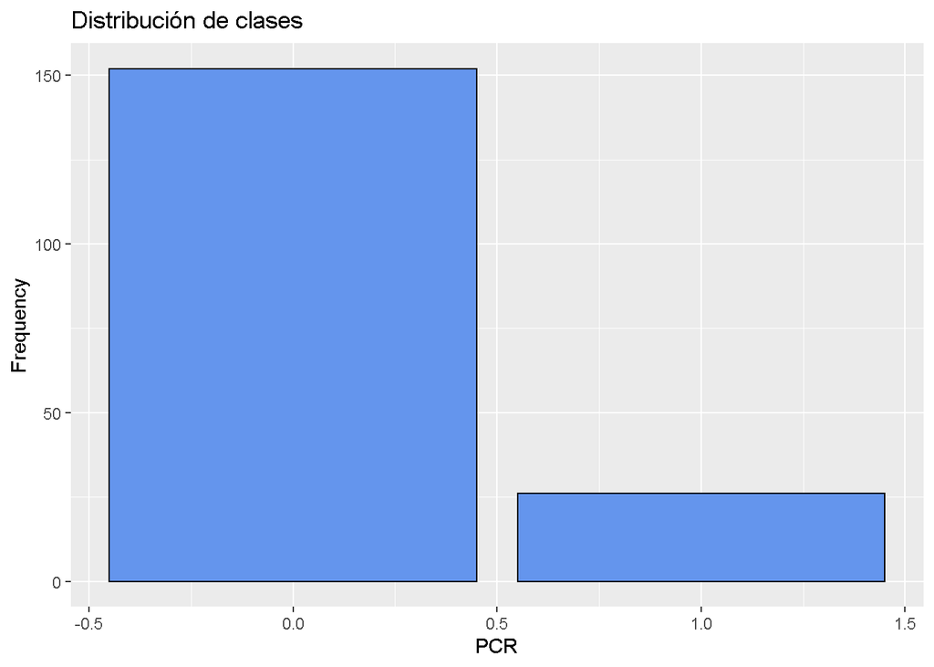

Otro aspecto a tener en cuenta de nuestro conjunto de datos son los valores nulos u observaciones en las que no tenemos información sobre algunas de sus características. En este caso tenemos un total de **32 valores nulos**, repartidos en **32 observaciones** y en **3 características**.

###### Distribucion valores null por columnas

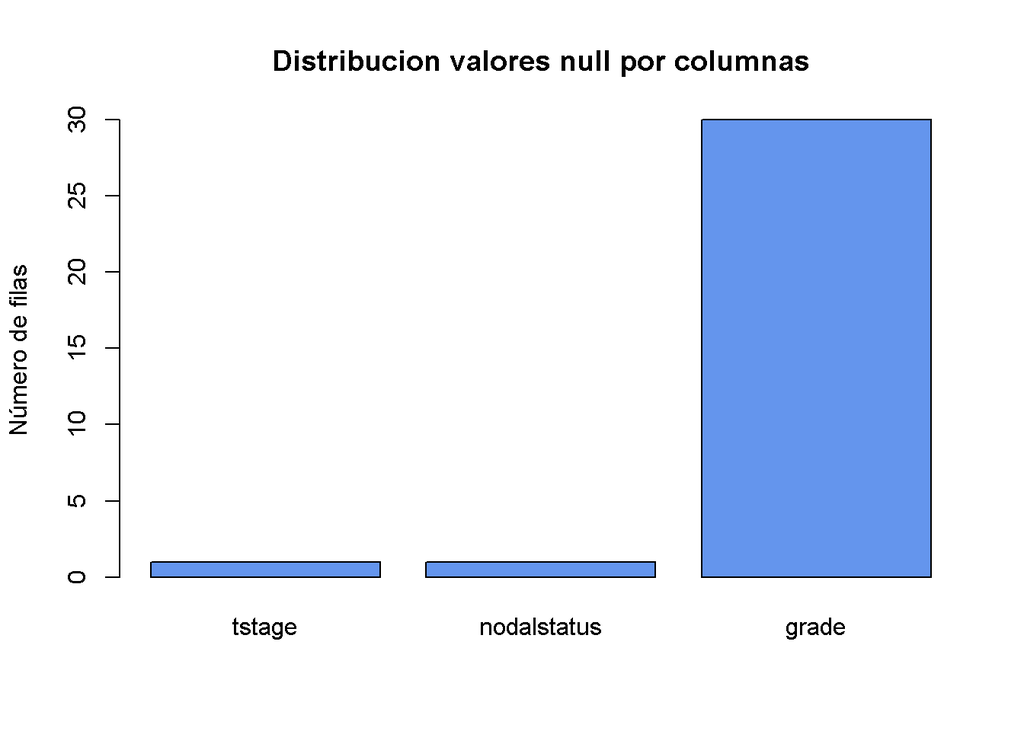

Teniendo en cuenta que si eliminasemos las 32 observaciones que contienen valores nulos perderiamos cerca de 20% de los datos aplicaremos imputación de valores perdidos.

#### 2.1.1 Estadística descriptiva e inferencia estadística

Se realizará un análisis estadístico descriptivo e inferencial de las variables clínico patológicas.

A partir del análisis descriptivo obtendremos las distribución de las variables, su dispersión, media o asimentría. Del análisis inferencial veremos el grado de relación entre las distintas variables.

#### 2.1.2 Imputación de valores perdidos

Como hemos mencionado anteriormente tenemos un total de 32 observaciones con valores perdidos, de los cuales se encuentran concentrados en 3 variables.

Los valores perdidos causan que las predicciones realizadas por los modelos estén sesgadas o que contengan ruido. Además algunos algoritmos no pueden ser aplicados en conjuntos de datos con valores perdidos. Todo esto provoca que tengan que ser tratados.

Las dos técnicas mas utilizadas en el tratamiento de valores perdidos son la eliminación de las observaciones o variables que los contengan y la imputación de estos.

En nuestro caso vamos a optar por la imputación de valores mediante ecuaciones encadenadas. Esta técnica es muy flexible en cuento a los tipos de variables a tratar a la vez. La técnica de ecuaciones encadenadas se basa en la información que aporta el total del conjunto de datos para predecir y asociar un valor a los valores perdidos. Con el fin de reducir incertidumbre estadística a las predicciones, cada predicción se realiza n veces, para finalmente seleccionar las predicción más frecuente. Con está técnica se pretende modificar lo menos posible la distribución original de los datos.

La imputación de valores la realizaremos mediante el paquete ‘MICE’.

Pasos a seguir:

- Seleccionamos el conjunto de datos en el que queremos aplicar la imputación de valores perdidos.
- Seleccionamos la técnica de predicción con la cual imputar los valores perdidos. Esta dependerá del tipo de variable. En nuestro utilzaremos ‘polyreg’ para variables categóricas no ordenadas con más de 2 categorías.
- Seleccionamos el conjunto de variables que se tomarán en cuenta para la predicción de los valores perdidos. En nuestro caso utilizamos todas las variables del conjunto de datos clínicos patológicos.
- Integramos en un dataset el conjunto de datos con los valores imputados.

#### 2.1.3 Selección de genes

La selección de genes tiene como objetivo eliminar aquellos genes que aporten ruido en la predicción, mejorar la interpretación de los modelos y reducir los recursos de cómputo. Como se ha mencionado la selección de genes nos va ha permitir obtener una visión más clara de cuales genes tienen mayor influencia en la predicción, situación clave en el contexto de nuestro problema.

Inicialmente del total de los 13516 genes, seleccionaremos los 50 más representativos.

El método que seleccionaremos en la selección de los 50 primeros genes será el **grado de correlación** de estos respecto de la variable target/PCR. Los genes seleccionados serán los que tengan un grado de correlación mayor, tanto positiva como negativa.

Teniendo en cuenta que los modelos no serán entrenados con más de 10 variables posteriormente se realizará una segunda selección de variables.

Los dos métodos seleccionados para esta segunda selección de variables estarán basados en la **significancia estadística** y en la **ganancia de información** de las variables independientes respecto de la variable target/PCR.

Los métodos de selección de variables seleccionados pertenecen al grupo de métodos de filtrado. Los métodos de filtrado utilizan la información estadística propia del conjunto de variables. Son computacionalmente menos costosos en comparación con métodos wrapper o embeddded. A su vez evitan un sobreajuste de los modelos a las variables seleccionadas.

`Hypothesis Filter`

```r
HypothesisFilter <- function(dataframe, ncolumns) {

data.frame.filter <- data.frame(Columna= character(), p.value = numeric())

for(k in 1:ncol(dataframe)) {
  valor <- BivariateFunction(dataframe[,"pcr"], dataframe[,k], dataframe)
  data.ite <- data.frame(Columna = names(dataframe)[k], p.value = valor)
  data.frame.filter <- rbind(data.frame.filter, data.ite)

}

data.frame.filter <- data.frame.filter[order(data.frame.filter$p.value, decreasing = FALSE),]

dataframe. <- dataframe[,data.frame.filter[1:ncolumns,]$Columna]

elements <- list(FullResults = data.frame.filter, dataframe = dataframe.)

return (elements)

}
```

`Correlation Filter`

```r
CorrelationFilter <- function(dataframe, ncolumns.) {

ncolumns <- ncolumns.+1
dataframe$pcr <- as.numeric(dataframe$pcr)

set.seed(7)
# calculate correlation matrix
correlationMatrix <- cor(dataframe)
# find attributes that are highly corrected
orderCorrelation <- order(abs(correlationMatrix[1,]), decreasing = TRUE)

list.corr. <- correlationMatrix[1,]

dataframe. <- dataframe[,names(correlationMatrix[1,orderCorrelation[2:ncolumns]])]

elements <- list(dataframe = dataframe., list.corr = list.corr.)

return (elements)

}
```

`Information Gain Filter`

```r
InformatioGainFilter <- function (dataframe, ncolumns.) {

IG.CORElearn <- attrEval(pcr==1 ~ ., data=dataframe,  estimator = "InfGain")

list.IG. <- IG.CORElearn

dataframe. <- dataframe[,names(IG.CORElearn[order(IG.CORElearn, decreasing = TRUE)[1:ncolumns.]])]
dataframe.$pcr <- dataframe$pcr

data.frame.results <- data.frame(Columns = names(IG.CORElearn[order(IG.CORElearn, decreasing = TRUE)]), IG = IG.CORElearn[order(IG.CORElearn, decreasing = TRUE)])

elements <- list(dataframe = dataframe., list.IG = data.frame.results)

return (elements)

}
```

`Bivariate Function`

```r
## Realiza una análsis bivariante de dos variables dadas.##########################################
##
## Variable1, variable2 = Par de vectores que representen variables a analizar
## Dataset = Conjunto de datos de tipo dataframe al cual pertenece las variables anteriores.
##
## **En el caso de introducir variables de tipo caracter se modificarán automaticamente a factor.
##
## Importante!!! La variable dependiente se posicionará en variable1.
BivariateFunction <- function(variable1,variable2, dataset) {


  ## Modifica variables de tipo caracter a factor.
  if(is.character(variable1)) {
    variable1 <- as.factor(variable1)
  }

  if(is.character(variable2)) {
    variable2 <- as.factor(variable2)
  }


  ## Analisis de dos variables categóricas
  if (is.factor(variable1) & (is.factor(variable2))){
    ## Creamos tabla de contigencia
    cont.tab <- xtabs(~variable1+variable2,data=dataset)
    ## Compramos que el número de observaciones es mayor o igual en todas las celdas para proceder       con test de chi cuadrado
    if(all(cont.tab)>=5) {
      chisqTest <- chisq.test(cont.tab)
      return(chisqTes$p.value)
    ## En el caso de que tengamos observaciones con valor menor a cinco procedemos a realizar           fisher.
    } else {
      fisherTest <- fisher.test(cont.tab,simulate.p.value=TRUE)
      return(fisherTest$p.value)
    }
  }

  ## Análisis de variable categórica vs numérica
  if(is.factor(variable1) & is.numeric(variable2) | is.numeric(variable1) & is.factor(variable2)) {

    ## Ordenamos las variables.
    if(is.factor(variable2)) {
      changVar1 <- variable1
      changVar2 <- variable2
      variable2 <- changVar1
      variable1 <- changVar2
    }

    ## Verificamos la distribución de las varibles
    ## Ho Shapiro = Datos siguen una distribución normal
    shap <- shapiro.test(variable2)
    shapPvalue <- shap$p.value

    ## En los casos que tengamos menos o dos categorias y la variable numérica no siga una normal
    if(length(levels(variable1)) <= 2 & shapPvalue <= 0.05) {
      ## Realizamos el test Wilcox test
        testWilcox <- wilcox.test(variable2 ~ variable1, data = dataset)
        return(testWilcox$p.value)
    }

    ## En los casos que tengamos más de dos categorias y la variable numérica no siga una normal
    if(length(levels(variable1)) > 2 & shapPvalue <= 0.05) {
      ## Realizamos el test Kruskal test
        testKruskal <- kruskal.test(variable2 ~ variable1, data = dataset)
        return(testKruskal$p.value)
    }

    ## En los casos que tengamos menos o dos categorias y la variable numérica siga una normal
    if(length(levels(variable1)) <= 2 & shapPvalue > 0.05) {
      ## Realizamos t-test
        testT <- t.test(variable2 ~ variable1, data = dataset)
        return(testT$p.value)
    }

    ## En los casos que tengamos mas dos categorias y la variable numérica siga una normal
    if(length(levels(variable1)) > 2 & shapPvalue > 0.05) {
      ## Realizamos t-test
        testAOVA <- aov(variable2 ~ variable1, data = dataset)
        return(testAOVA$coeficcients[2])
    }

  }

  ##Análisis variable numérica vs numérica
  if(is.numeric(variable1) & is.numeric(variable2)) {

    ## Verificamos la distribución de las varibles
    ## Ho Shapiro = Datos siguen una distribución normal
    shap_v1 <- shapiro.test(variable1)
    shapPvalue_v1 <- shap_v1$p.value
    shap_v2 <- shapiro.test(variable2)
    shapPvalue_v2 <- shap_v2$p.value
    ## Obtenemos el valor máximo de los p.values para comprobar que las dos siguen una normal
    shapPvalue <- max(shapPvalue_v1,shapPvalue_v2)

    ## En los casos que la variable numérica no siga una normal
    if(shapPvalue <= 0.05) {
      ## Realizamos un test de correlación de Spearman
        testSpearman <- cor.test(variable2, variable1, alternative="two.sided", method="spearman",          exact=FALSE)
        return(testSpearman$p.value)
    }

    ## En los casos que la variable numérica siga una normal
    if(shapPvalue > 0.05) {
      ## Realizamos un test de correlación de Pearson
        testPearson <- cor.test(variable2, variable1, alternative="two.sided", method="pearson")
        return(testPearson$p.value)
    }

  }



}
```

#### 2.1.4 Codificación de variables

Como mencionamos inicialmente nuestro conjunto de datos está compuesto por variables categóricas y numéricas. Los algoritmos tanto de aprendizaje computacional como los aplicados en el sobremuestreo de instancias realizan sus funciones a través de operaciones matemáticas. Es por esto que es necesario aplicar una codificación a las variables categóricas presentes.

Las técnicas de codificación de variables que aplicaremos son **LabelEncoder** y **One Hot Encoder**.

> Label Encoder asocia a cada categoría un entero basado en el orden alfabético.

> One Hot Encoder por cada categoria crea una nueva variable y asocia los valores de 1 o 0 a su presencia o no, respectivamente.

`Label Endoder Function`

```r
LabelEncoderFunction <- function(dataframe) {

dataframe. <- na.omit(dataframe)
factors <- names(which(sapply(dataframe., is.factor)))

lbl <- LabelEncoder$new()
for (i in factors){
  lbl$fit(dataframe.[,i])
  dataframe.[,i]<- lbl$fit_transform(dataframe.[,i])
}

dataframe.

return(dataframe.)

}
```

##### 2.1.4.1 Estandarización de los datos

Algunos algoritmos otorgan el peso a la variable en base al valor de esta. Esto quiere decir que las variables que contengan valores mayores tendrán una mayor influencia sobre el modelo.

Las variables presentes en un dataset pueden proceder de diversas fuentes y estar representadas en diversas escalas. Por esto es necesario igualar las escalas de las variables presentes en un dataset para que el peso atribuido a cada una no se vea influido por su escala.

En nuestro conjunto de datos se procederá a estandarizar las escalas de las variables clínico patológicas y las correspondientes a marcadores genéticos.

No obstante no siempre el escalado de variables es aconsejable. Se debe de tener en consideración el rango de las variables y la presencia de valores outliers ya que pueden potenciar el ruido en el conjunto de datos.

##### 2.1.5 Técnicas de sobremuestreo

El problema del desbalanceo de clases es cuando el número de instanciass de una determinada clase no esta igualmente distribuida respecto del resto. Esto crea que los modelos no sean capaces de generalizar correctamente y realize predicciones sesgadas hacia la clase mayoritaria. En el ámbito médico esto es especialmente común, afortunadamente, por la proporcion entre observaciones pertenecientes a individuos sanos respecto de los enfermos. A su vez con el aumento en la disposición de los datos y por consiguiente de la identificación de distintos subgrupos dentro de los conocidos, el problema del desbalanceo está obteniendo especial relevancia.

En nuestro caso aplicaremos la técnica de sobremuestreo SMOTE en los conjuntos de entrenamiento. Las técnicas de sobremuestreo como SMOTE no se aplican en los conjuntos de test con el objetivo de que este represente la distribución real de los datos. El sobremuestreo tiene su función en proporcionarle al modelo un entrenamiento lo más general posible evitando sesgos por la distribución de clases. **SMOTE** es una técnica de sobremuestreo la cual crea datos sintéticos de la clase minoritaria.

> SMOTE selecciona una instancia de la clase minoritaria al azar y marca los k vecinos minoritarios más cercanos a esta. Las instancias sintéticas serán añadidas entre estas y los vecinos seleccionados.

#### 2.6 Algoritmos aplicados

Se utilizarán los modelos regresión logística, ANN, SVM y árboles de decisión.

- **Neural Networks**

Las redes neuronales es un subconjunto del machine learning inspirado en el comportamiento del cerebro humano y la forma biológica en la que las neuronas llevan a cabo sus funciones.

Estan formadas por un conjunto de neuronas estructuradas por capas. Se diferencian tres tipos de capas, input, hidden y output. Y la toma de decisión esta dirigida por una serie de pesos y valores humbrales.

Estos contienen una serie de parámetros que permiten controlar la complejidad del modelo o capacidad de generalización.

En este apartado se crearan varios modelos de redes neuronales artificiales, cada uno de ellos con una combianción de los parámetros mas representativos de estos.

Los parámetros a partir de los cuales formaremos las distintas configuraciones son el **número de neuronas** de la capa oculta y el **weight decay**.

La elección del número de neuronas no tiene una regla fija. Es aconsejable que el número de neuronas de la capa oculta este entre el tamaño de las variables de entrada y salida. Valores excesivamente altos del número de neuronas derivan en overfitting por la facilidad que tendrán estas de memorizar cada situación presentada en el conjunto de entrenamiento.

En relación al valor weight decay usualmente se suele tomar 0.1 o 0.01. Valores altos de weight decay provocarán un aumento excesivo del control de la complejidad del modelo que no será capaz de ‘adaptarse’ correctamente. De forma inversa valores excesivamente bajos de weight decay provocarán que la complejidad del modelo no este limitada y la función resultante se ajuste demasiado a los datos del modelo, generando así overfitting.

- **Decision Trees**

Los arboles de decisión son un tipo de algoritmo de clasificación los cuales tienen una representación similar a la forma de un arbol. Los arboles de decisión están formados por nodos que denotan decisiones a tomar sobre la presencia de un atributo y sus ramas representan los posibles resultados.

Las ventajas mas significativas de los arboles de decisión son su facilidad de interpretación y el costo computacional de las predicciones. Entre las mayores desventajes destacamos la posibilidad de creación de arboles demasiados complejos y la inestabilidad ante pequeños cambios en los datos.

Crearemos varios modelos Decision Tree buscando el parámetro Cp que proporcione mejores resultados.

El parámetro **Cp** controla el alcance en la complejidad del arbol generado.

Los valores de Cp se encuentran en el rango entre 0 y 1, siendo un arbol con complejidad máxima el correspondiente al valor 0 y un arbol sin divisiones al valor 1.

- **SVM**

El objetivo de SVM es encontrar la mejor linea o hiperplano que clasifique optimamente las distintas instancias de un conjunto de datos.

A través de los parámetros de **C** y **Gamma** se puede controlar como ajustar la superficie de decisión al conjunto de datos. El valor de C marca el margen de error de la superficie o linea de decisión (número de instancias en zona no perteneciente a su clase). Con el valor de gamma controlamos como la curva de superficie de decisión se ajusta al conjunto de entrenamiento.

- **Logistic Regression**

La regresión logística clasifica instancias en un conjunto discreto de clases. Se diferencia con la regresión lineal en la salida. La regresión logística devuelve un valor de probabilidad a partir del cual se mapean las observaciones en clases discretas. Existen varios tipos de regresión logística (binaria, multiclase y ordinal). El mapeo de clases utiliza un rango de decisión.

#### 2.2 Métricas

Las métricas que usaremos para evaluar los modelos serán ACC, Precision, AUC, RECALL y F1 Score.

- **ACC**

Representa el ratio de predicciones correctas sobre el total de datos de entrada.

ACC = (TP+TN)/(TP+TN+FP+FN)

Rango ACC [0,1]. Valores altos de ACC determinan mejor rendimiento del modelo.

- **Precision**

Representa el ratio de predicciones correctas positivas sobre el total de predicciones positivas realizadas

Precision = (TP)/(TP+FP)

Rango Precision [0,1]. Valores altos de Precision determinan mejor rendimiento del modelo

- **AUC (Area Under the)**

Determina la capacidad del modelo para distinguir entre clases. Es aplicada en problemas de clasificación binária. La curva ROC estima la probabilidad de que un modelo clasifique una instancia positiva elegida al azar más alto que una instacia negativa elegida al azar

Rango de AUC [0,1]. Valores altos de AUC determinan mejor rendimiento del modelo.

- **RECALL**

Determina la cantidad de instancias postivas que el modelo es capaz de identificar.

RECALL = (TP)/(TP+FN)

Rango de RECALL [0,1]. Valores altos de RECALL determinan mejor rendimiento del modelo.

- **F1 Score**

Determina como de preciso y exhaustivo/robusto es el modelo. Es calculada a partir de la media harmónica ente precisión y recall. Asume que importa de igual forma la precisión y recall. Esto puede ser modificado dependiendo del contexto del problema.

Rango de F1 Score [0,1]. Valores altos de F1 Score determinan mejor rendimiento del modelo.

`Outer loop Cross Validation 5x2`

```r
outerloop <- function(data, model, parameters, ncolumns, smote) {


  ## Almacenamos los resultados del inner loop.
  FoldsResults. <- list()

  ## Realizamos las 5 particiones de los datos
  Folds <- createFolds(data$pcr,5)


  ## DataFrame de resultados
  data.frame.metricas <- data.frame(Iteracion = character(), Modelo=character(), Parametro1=character(), Parametro2=character(), TecnicaFS = character(), NColumnas = numeric(), ACC.train = numeric(), ACC.test = numeric(), Precision.train = numeric(), Precision.test=numeric(), AUC.train = numeric(), AUC.test = numeric(), RECALL.train = numeric(), RECALL.test = numeric(), F1.train = numeric(), F1.test = numeric())

  ## Lista de parámetros
  param.list <- parameters

  ## Codificamos las variables categóricas
  data.LE <- LabelEncoderFunction(data)

  for(k in Folds) {


    ## Inicializamos las variables que contendrán los valores ACC training y ACC test respectivamente
    ACC.cross.val <- 0.0
    ACC.cross.val.test <- 0.0
    AUC.cross.val <- 0.0
    AUC.cross.val.test <- 0.0

    ## Conjunto de datos de training
    datos.cross.val <- data.LE[-k,]

    ## Cargamos los elementos de innerLoop
    inner.loop <- innerLoop(datos.cross.val, model, parameters, ncolumns, smote)
    best.parameter1 <- inner.loop$BestParameter1
    best.parameter2 <- inner.loop$BestParameter2
    best.TecnicaFS <- inner.loop$BestFS
    FoldsResults.[[1+length(FoldsResults.)]] <- inner.loop$Results

    ## Seleccionamos la técnica de selección de variables
    if(best.TecnicaFS == "HypothesisFilter") {

      data.FS <- HypothesisFilter(data.LE,ncolumns)$dataframe

    }

    if(best.TecnicaFS == "InformationGainFilter") {

      data.FS <- InformatioGainFilter(data.LE,ncolumns)$dataframe

    }

    ## SMOTE
    if (smote == TRUE) {

      ## Aplicamos SMOTE
      datos.cross.val <- SMOTE(data.FS, data.FS$pcr, K=4)$data
      datos.cross.val$class <- NULL
      datos.cross.val <- datos.cross.val[-k,]

    } else {

      ## Conjunto de datos de training
      datos.cross.val <- data.FS[-k,]

    }


    ## Conjunto de datos de test
    datos.test.cross.val <- data.FS[k,]


    ## Selección de modelos
    if(model== "dt") {

      ## Decision tree
      dt.fit <- rpart(pcr=="1"~., data=datos.cross.val, control = rpart.control(cp=as.numeric(best.parameter1)))

      ## Predecimos las respuesta con el conjunto de training
      predic.training <- predict(dt.fit, datos.cross.val)

      ## Predecimos las respuesta con el conjunto de test
      predic.test <- predict(dt.fit, datos.test.cross.val)

    }

    if(model== "nnet") {

      neu <- as.numeric(best.parameter1)
      decay. <- as.numeric(best.parameter2)
      max.ite <- as.numeric(100)

      ## Red neuronal nnet
      nn.fit <- nnet(pcr=="1"~ ., data=datos.cross.val, size=neu,entropy=TRUE,maxit=100, decay=decay., MaxNWts=4000,trace=FALSE)

      ## Predecimos las respuesta con el conjunto de training
      predic.training <- predict(nn.fit, datos.cross.val, type="class")

      ## Predecimos las respuesta con el conjunto de test
      predic.test <- predict(nn.fit, datos.test.cross.val, type="class")
    }

    if(model== "svm") {

      gamma. <- as.numeric(best.parameter1)
      cost. <- as.numeric(best.parameter2)

      ## Support Vector Machines
      svm.fit <- svm(pcr=="1" ~ ., cost=cost., data=datos.cross.val,type="C-classification", kernel="radial", gamma=gamma., probability=TRUE)

      ## Predecimos las respuesta con el conjunto de training
      pred <- predict(svm.fit, datos.cross.val, probability=TRUE)
      predic.training <- attr(pred, which="probabilities")[,"TRUE"]

      ## Predecimos las respuesta con el conjunto de test
      pred <- predict(svm.fit, datos.test.cross.val, probability=TRUE)
      predic.test <- attr(pred, which="probabilities")[,"TRUE"]

    }

    if(model=="rl") {

      ## Modelo de regresión logística con todas las variables
      log.reg <- glm(pcr=="1"~ ., data = datos.cross.val, family = binomial("logit"))


      ## Predecimos las respuesta con el conjunto de training
      predic.training <- predict(log.reg, newdata = datos.cross.val, type = "response")

      ## Predecimos las respuesta con el conjunto de test
      predic.test <- predict(log.reg, newdata = datos.test.cross.val,type = "response")

    }

    ## Binarizamos la respuesta
    predic.training[predic.training >= 0.5] <- 1
    predic.training[predic.training < 0.5] <- 0
    predic.test[predic.test >= 0.5] <- 1
    predic.test[predic.test < 0.5] <- 0

    ## Obtenemos los TP,TN,FP,FN training
    true.pos.cross.val <- sum(predic.training == 1 & datos.cross.val$pcr == 1)
    true.neg.cross.val <- sum(predic.training == 0 & datos.cross.val$pcr == 0)
    false.neg.cross.val <- sum(predic.training == 0 & datos.cross.val$pcr == 1)
    false.pos.cross.val <- sum(predic.training == 1 & datos.cross.val$pcr == 0)

    ## ACC, RECALL y F1 score training
    ACC.cross.val.vector <- (true.pos.cross.val+true.neg.cross.val)/length(datos.cross.val$pcr)
    precision.cross.val <- (true.pos.cross.val)/(true.pos.cross.val+false.pos.cross.val)
    RECALL.cross.val <- (true.pos.cross.val)/(true.pos.cross.val+false.neg.cross.val)
    F1.cross.val <- (2*RECALL.cross.val*ACC.cross.val.vector/(RECALL.cross.val+ACC.cross.val.vector))

    ## Obtenemos los TP y TN test
    true.pos.test.cross.val <- sum(predic.test == 1 & datos.test.cross.val$pcr == 1)
    true.neg.test.cross.val <- sum(predic.test == 0 & datos.test.cross.val$pcr == 0)
    false.neg.test.cross.val <- sum(predic.test == 0 & datos.test.cross.val$pcr == 1)
    false.pos.test.cross.val <- sum(predic.test == 1 & datos.test.cross.val$pcr == 0)
    ACC.test.cross.val.vector <-(true.pos.test.cross.val+true.neg.test.cross.val)/length(datos.test.cross.val$pcr)

    ## ACC, RECALL y F1 score test
    RECALL.test.cross.val <- (true.pos.test.cross.val)/(true.pos.test.cross.val+false.neg.test.cross.val)
    precision.test.cross.val <- (true.pos.test.cross.val)/(true.pos.test.cross.val+false.pos.test.cross.val)
    F1.test.cross.val <- (2*RECALL.test.cross.val*ACC.test.cross.val.vector/(RECALL.test.cross.val+ACC.test.cross.val.vector))

    ## Obtenemos AUC training de cada iteración
    dataAUC.train.cross.val <- data.frame(predictions = predic.training, PCR = datos.cross.val$pcr)
    data(dataAUC.train.cross.val)
    pred.AUC.cross.val <- prediction(as.numeric(dataAUC.train.cross.val$predictions), dataAUC.train.cross.val$PCR)
    perf.AUC.cross.val <- performance(pred.AUC.cross.val, "auc")
    AUC.value.cross.val <- perf.AUC.cross.val@y.values[[1]]

    ## Obtenemos AUC test de cada iteración
    dataAUC.test.cross.val <- data.frame(predictions = predic.test, PCR = datos.test.cross.val$pcr)
    data(dataAUC.test.cross.val)
    pred.AUC.cross.val.test <- prediction(as.numeric(dataAUC.test.cross.val$predictions), dataAUC.test.cross.val$PCR)
    perf.AUC.cross.val.test <- performance(pred.AUC.cross.val.test, "auc")
    AUC.value.test.cross.val <- perf.AUC.cross.val.test@y.values[[1]]

    ## Añadimos los resultado de la iteración al dataframe de resultado
    data.frame.metricas.add <- data.frame(Iteracion = c("Parcial"), Modelo = c(model), Parametro1 =best.parameter1, Parametro2 =best.parameter2, TecnicaFS = c(best.TecnicaFS),NColumnas = c(ncolumns), ACC.train = c(ACC.cross.val.vector), ACC.test = c(ACC.test.cross.val.vector),Precision.train = c(precision.cross.val), Precision.test=c(precision.test.cross.val), AUC.train = c(AUC.value.cross.val), AUC.test = c(AUC.value.test.cross.val), RECALL.train = c(RECALL.cross.val), RECALL.test = c(RECALL.test.cross.val), F1.train = c(F1.cross.val), F1.test = c(F1.test.cross.val))
    data.frame.metricas <- rbind(data.frame.metricas,data.frame.metricas.add);


  }

  ## Añadimos los resultado de la iteración al dataframe de resultado
  data.frame.metricas.global <- data.frame(Iteracion = c("Global"), Modelo = c(model), Parametro1 =c(NA),Parametro2 =c(NA),TecnicaFS = c(NA), NColumnas = c(ncolumns), ACC.train=c(mean(data.frame.metricas$ACC.train)), ACC.test = c(mean(data.frame.metricas$ACC.test)),Precision.train = c(mean(data.frame.metricas$Precision.train)), Precision.test= c(mean(data.frame.metricas$Precision.test)), AUC.train = c(mean(data.frame.metricas$AUC.train)), AUC.test = c(mean(data.frame.metricas$AUC.test)), RECALL.train = c(mean(data.frame.metricas$RECALL.train)), RECALL.test = c(mean(data.frame.metricas$RECALL.test)), F1.train = c(mean(data.frame.metricas$F1.train)), F1.test = c(mean(data.frame.metricas$F1.test)))
  data.frame.metricas <- rbind(data.frame.metricas,data.frame.metricas.global);

  ## Devolvemos dataframe con resultado por outer folds y best parameter.
  elements <- list(Results = data.frame.metricas, NameParametro1 = names(parameters[[1]][1]), NameParametro2 = names(parameters[[2]][1]), FoldsResults = FoldsResults.)


  return(elements)

}
```

`Inner loop Cross Validation 5x2`

```r
innerLoop <- function(data, model, parameters, ncolumns, smote ) {

  ## Dataframe de resultados
  data.frame.metricas <- data.frame(Model = character(), Parametro1=character(), Parametro2=character(), TecnicaFS = character(), ACC.train = numeric(), ACC.test = numeric(),Precision.train = numeric(), Precision.test=numeric(), AUC.train = numeric(), AUC.test = numeric(), RECALL.train = numeric(), RECALL.test = numeric(), F1.train = numeric(), F1.test = numeric())

  ## Codificamos las variables categóricas
  data.LE <- LabelEncoderFunction(data)


  ## Lista de parámetros
  param.list <- parameters

  ## Técnicas Feature Selection
  tecnicas.fs <- c("HypothesisFilter", "InformationGainFilter")


  for(m in 1:length(tecnicas.fs)) {



    ##Aplicamos método de selección de variables
    if(tecnicas.fs[m] == "HypothesisFilter") {

      data <- HypothesisFilter(data.LE, ncolumns)$dataframe

    }

    if(tecnicas.fs[m] == "InformationGainFilter") {

      data <- InformatioGainFilter(data.LE, ncolumns)$dataframe

    }

    ## Realizamos las particiones de los datos
    train.folds <- createFolds(data$pcr,2)

    for (k in 1:length(parameters[[1]][[1]])) {

    for(j in  1:length(parameters[[2]][[1]])) {

      # j <- 1

      ## Inicializamos las variables que contendrán los valores AUC/ACC train y AUC/ACC validation
      ACC.train.val <- 0.0
      ACC.test.val <- 0.0
      AUC.train.val <- 0.0
      AUC.test.val <- 0.0
      RECALL.cross.val <- 0.0
      RECALL.test.cross.val <- 0.0
      F1.cross.val <- 0.0
      F1.test.cross.val <- 0.0
      precision.cross.val <- 0.0
      precision.test.cross.val <- 0.0


      for(i in train.folds) {



        ## Conjunto de datos de training
        datos.training <- data[i,]

        ## SMOTE
        if (smote == TRUE) {

          ## Aplicamos SMOTE
          datos.training <- SMOTE(datos.training, datos.training$pcr, K=4)$data
          datos.training$class <- NULL
          datos.training <- datos.training[-i,]

        }


        ## Conjunto de datos de validacion
        datos.validation <- data[-i,]


        if(model == "dt") {


          cp. <- as.numeric(parameters[[1]][[1]][k])

          ## Decision tree
          dt.fit <- rpart(pcr=="1"~., data=datos.training, control = rpart.control(cp = cp.))

          ## Predecimos las respuesta con el conjunto de training
          predic.training <- predict(dt.fit, datos.training)

          ## Predecimos las respuesta con el conjunto de validacion
          predic.test <- predict(dt.fit, datos.validation)

        }

        if(model== "nnet") {

          neu <- as.numeric(parameters[[1]][[1]][k])
          decay. <- as.numeric(parameters[[2]][[1]][j])
          max.ite <- as.numeric(100)

          ## Red neuronal nnet
          nn.fit <- nnet(pcr==1~ ., data=datos.training, size=neu,entropy=TRUE,maxit=100, decay=decay., MaxNWts=4000,trace=FALSE)

          ## Predecimos las respuesta con el conjunto de training
          predic.training <- predict(nn.fit, datos.training, type="class")

          ## Predecimos las respuesta con el conjunto de test
          predic.test <- predict(nn.fit, datos.validation, type="class")
        }

        if(model== "svm") {


          gamma. <- as.numeric(parameters[[1]][[1]][k])
          cost. <- as.numeric(parameters[[2]][[1]][j])

          ## Support Vector Machines
          svm.fit <- svm(pcr==1 ~ ., cost=cost., data=datos.training,type="C-classification", kernel="radial", gamma=gamma., probability=TRUE)

          ## Predecimos las respuesta con el conjunto de training
          pred <- predict(svm.fit, datos.training, probability=TRUE)
          predic.training <- attr(pred, which="probabilities")[,"TRUE"]

          ## Predecimos las respuesta con el conjunto de test
          pred <- predict(svm.fit, datos.validation, probability=TRUE)
          predic.test <- attr(pred, which="probabilities")[,"TRUE"]

        }

        if(model=="rl") {

          ## Modelo de regresión logística con todas las variables
          log.reg <- glm(pcr=="1"~ ., data = datos.training, family = binomial("logit"))


          ## Predecimos las respuesta con el conjunto de training
          predic.training <- predict(log.reg, newdata = datos.training, type = "response")

          ## Predecimos las respuesta con el conjunto de test
          predic.test <- predict(log.reg, newdata = datos.validation,type = "response")

        }


        ## Binarizamos la respuesta
        predic.training[predic.training >= 0.5] <- 1
        predic.training[predic.training < 0.5] <- 0
        predic.test[predic.test >= 0.5] <- 1
        predic.test[predic.test < 0.5] <- 0


        ## Obtenemos los TP,TN,FP,FN training
        true.pos.cross.val <- sum(predic.training == 1 & datos.training$pcr == 1)
        true.neg.cross.val <- sum(predic.training == 0 & datos.training$pcr == 0)
        false.neg.cross.val <- sum(predic.training == 0 & datos.training$pcr == 1)
        false.pos.cross.val <- sum(predic.training == 1 & datos.training$pcr == 0)
        ACC.train.val.vector <- (true.pos.cross.val+true.neg.cross.val)/length(datos.training$pcr)

        ## ACC, RECALL, Precision y F1 score training
        ACC.train.val <- ACC.train.val+ACC.train.val.vector
        precision.cross.val. <- (true.pos.cross.val)/(true.pos.cross.val+false.pos.cross.val)
        RECALL.cross.val. <- (true.pos.cross.val)/(true.pos.cross.val+false.neg.cross.val)
        F1.cross.val. <- (2*RECALL.cross.val*precision.cross.val./(RECALL.cross.val+precision.cross.val.))

        RECALL.cross.val <- RECALL.cross.val + RECALL.cross.val.
        F1.cross.val <- F1.cross.val + F1.cross.val.
        precision.cross.val <- precision.cross.val + precision.cross.val.


        ## Obtenemos los TP y TN test
        true.pos.test.cross.val <- sum(predic.test == 1 & datos.validation$pcr == 1)
        true.neg.test.cross.val <- sum(predic.test == 0 & datos.validation$pcr == 0)
        false.neg.test.cross.val <- sum(predic.test == 0 & datos.validation$pcr == 1)
        false.pos.test.cross.val <- sum(predic.test == 1 & datos.validation$pcr == 0)
        ACC.test.cross.val.vector <-(true.pos.test.cross.val+true.neg.test.cross.val)/length(datos.validation$pcr)

        ## ACC, RECALL,Precision y  F1 score test
        ACC.test.val <- ACC.test.val+ACC.test.cross.val.vector
         precision.test.cross.val. <- (true.pos.test.cross.val)/(true.pos.test.cross.val+false.pos.test.cross.val)
        RECALL.test.cross.val. <- (true.pos.test.cross.val)/(true.pos.test.cross.val+false.neg.test.cross.val)
        F1.test.cross.val. <- (2*RECALL.test.cross.val*ACC.test.cross.val.vector/(RECALL.test.cross.val+ACC.test.cross.val.vector))
        precision.test.cross.val <- precision.test.cross.val + precision.test.cross.val.
        RECALL.test.cross.val <- RECALL.test.cross.val + RECALL.test.cross.val.
        F1.test.cross.val <- F1.test.cross.val + F1.test.cross.val.


        ## Obtenemos AUC training de cada iteración
        dataAUC.train.cross.val <- data.frame(predictions = predic.training, pcr = datos.training$pcr)
        data(dataAUC.train.cross.val)
        pred.AUC.train.val <- prediction(as.numeric(dataAUC.train.cross.val$predictions), dataAUC.train.cross.val$pcr)
        perf.AUC.train.val <- performance(pred.AUC.train.val, "auc")
        AUC.value.cross.val <- perf.AUC.train.val@y.values[[1]]
        AUC.train.val <- AUC.train.val + AUC.value.cross.val

        ## Obtenemos AUC test de cada iteración
        dataAUC.test.cross.val <- data.frame(predictions = predic.test, pcr = datos.validation$pcr)
        data(dataAUC.test.cross.val)
        pred.AUC.test.val <- prediction(as.numeric(dataAUC.test.cross.val$predictions), dataAUC.test.cross.val$pcr)
        perf.AUC.test.val <- performance(pred.AUC.test.val, "auc")
        AUC.value.test.cross.val <- perf.AUC.test.val@y.values[[1]]
        AUC.test.val <- AUC.test.val + AUC.value.test.cross.val

      }

      ACC.train.val <- ACC.train.val/2
      ACC.test.val <- ACC.test.val/2
      AUC.test.val <- AUC.test.val/2
      AUC.train.val <- AUC.train.val/2
      RECALL.cross.val <- RECALL.cross.val/2
      RECALL.test.cross.val <- RECALL.test.cross.val/2
      F1.cross.val <- F1.cross.val/2
      F1.test.cross.val <- F1.test.cross.val/2
      precision.cross.val <- precision.cross.val/2
      precision.test.cross.val <- precision.test.cross.val/2


      data.frame.add <- data.frame(Model = model, Parametro1=as.character(parameters[[1]][[1]][k]),Parametro2=as.character(parameters[[2]][[1]][j]), TecnicaFS = tecnicas.fs[m], ACC.train = ACC.train.val, ACC.test = ACC.test.val, Precision.train = c(precision.cross.val), Precision.test=c(precision.test.cross.val),AUC.train = AUC.train.val, AUC.test = AUC.test.val, RECALL.train = c(RECALL.cross.val), RECALL.test = c(RECALL.test.cross.val), F1.train = c(F1.cross.val), F1.test = c(F1.test.cross.val))
      data.frame.metricas <- rbind(data.frame.metricas,data.frame.add)
      data.frame.metricas <- data.frame.metricas[order(data.frame.metricas$AUC.test, decreasing = TRUE), ]



    }
  }

  }

  elements <- list(Results = data.frame.metricas, BestParameter1 = data.frame.metricas$Parametro1[1], BestParameter2 = data.frame.metricas$Parametro2[1], BestFS = data.frame.metricas$TecnicaFS[1])





  return(elements)

}
```

## Resultados:

#### Imputación de valores perdidos

**Tecnica de predicción aplicada en cada variable**

```
##         age       erihc       prihc        her2      tstage nodalstatus
##          ""          ""          ""          ""   "polyreg"   "polyreg"
##       grade         pcr
##   "polyreg"          ""
```

**Tabla de predicciones**

Muestra las variables tomadas en cuenta o tomadas como predictores en la imputación de valores. Optamos por tener en cuenta todas las variables del conjunto de datos clínico patológicos

```
##             age erihc prihc her2 tstage nodalstatus grade pcr
## age           0     1     1    1      1           1     1   1
## erihc         1     0     1    1      1           1     1   1
## prihc         1     1     0    1      1           1     1   1
## her2          1     1     1    0      1           1     1   1
## tstage        1     1     1    1      0           1     1   1
## nodalstatus   1     1     1    1      1           0     1   1
## grade         1     1     1    1      1           1     0   1
## pcr           1     1     1    1      1           1     1   0
```

**Verificamos la imputación de valores perdidos**

```
##         age       erihc       prihc        her2      tstage nodalstatus
##           0           0           0           0           0           0
##       grade         pcr
##           0           0
```

##### Inspeccionamos distribución de los conjuntos de datos original y imputado

La inspección de la distribución de los conjuntos de datos original y imputados la realizaremos utilizando el test de chi cuadrado.

```
##
##  Pearson's Chi-squared test
##
## data:  table(datos$tstage, datos.CP$tstage)
## X-squared = 708, df = 16, p-value < 2.2e-16
```

```
##
##  Pearson's Chi-squared test
##
## data:  table(datos$grade, datos.CP$grade)
## X-squared = 296, df = 4, p-value < 2.2e-16
```

```
##
##  Pearson's Chi-squared test
##
## data:  table(datos$nodalstatus, datos.CP$nodalstatus)
## X-squared = 531, df = 9, p-value < 2.2e-16
```

Como vemos la imputación de valores perdidos no ha influido en la distribución original de los datos.

#### Seleccionamos los 50 genes más representitvos según su correlación con la variable dependiente

```r
##datos.G50 <- CorrelationFilter(datos.G, 50)
```

**Nombres de los 50 genes seleccionados**

```
##                                                                                               Nombres50Gen
## 1  AC128677.4.....CH17.132F21.1.....IGKV1OR.1.....IGKV1OR.1.....IGKV1OR10.1.....IGKV1OR10.1.....IGKV1OR2.2
## 2                                                                                    IGKV1.17.....IGKV1.17
## 3                                                                                HLA.DQA1.....LOC100509457
## 4                                                        IGKV1.37.....IGKV1.37.....IGKV1D.37.....IGKV1D.37
## 5                                                                            IGKV1OR2.108.....IGKV1OR2.108
## 6                                                                                    IGHV3.73.....IGHV3.73
## 7                                                                                                 HLA.DQB1
## 8                                                                                             IGK.....IGKC
## 9                                                                                                     IGKC
## 10                                                                         IGLJ3.....IGLV3.19.....IGLV3.19
## 11                                                                                                   CXCL9
## 12                                                                                                    CD74
## 13                                                                                                  NECAP2
## 14                                                                               HLA.DQB1.....LOC101060835
```

[output cut: 36 more lines]

##### Creamos conjunto de datos clínico patológico One Hot Encoder

```r
datos.CP.oneHC <- dummy(datos.CP[1:7])
```

##### Combinamos datos clínicos patológicos y los 50 genes marcadores más representativos - Normalizados + One Hot Encoder

```r
# datos.CP.G50.normal <- cbind(datos.CP.oneHC,datos.G50);
# datos.CP.G50.normal <- as.data.frame(scale(datos.CP.G50.normal,center=T,scale=T))
# datos.CP.G50.normal$pcr <- datos$pcr
```

##### Combinamos clínicos patológicos y los 50 genes marcadores más representativos - Sin normalizar

```r
datos.CP.G50 <- cbind(datos.CP,datos.G50);
```

#### Análisis univariante

##### Resumen de distribución de las variables clínico patológicas

```
##       age        erihc  prihc  her2    tstage nodalstatus grade
##  Min.   :26.00   N:80   N:95   N:152   0: 2   0:59        1:17
##  1st Qu.:43.25   P:98   P:83   P: 26   1:11   1:72        2:66
##  Median :49.00                         2:76   2:38        3:95
##  Mean   :50.92                         3:38   3: 9
##  3rd Qu.:59.00                         4:51
##  Max.   :74.00
##       pcr
##  Min.   :0.0000
##  1st Qu.:0.0000
##  Median :0.0000
##  Mean   :0.1461
##  3rd Qu.:0.0000
##  Max.   :1.0000
```

##### Características de las variables clínico patológicas

```
## 'data.frame':    178 obs. of  8 variables:
##  $ age        : int  48 55 45 39 49 39 48 73 42 42 ...
##  $ erihc      : Factor w/ 2 levels "N","P": 1 2 1 2 2 1 1 1 2 2 ...
##  $ prihc      : Factor w/ 2 levels "N","P": 1 2 1 1 1 1 2 2 2 2 ...
##  $ her2       : Factor w/ 2 levels "N","P": 1 1 2 1 1 2 2 1 1 1 ...
##  $ tstage     : Factor w/ 5 levels "0","1","2","3",..: 3 4 3 3 2 4 4 4 4 3 ...
##  $ nodalstatus: Factor w/ 4 levels "0","1","2","3": 3 1 1 3 1 2 2 1 2 2 ...
##  $ grade      : Factor w/ 3 levels "1","2","3": 3 2 3 2 1 2 3 3 2 3 ...
##  $ pcr        : int  1 0 0 0 0 0 0 0 0 0 ...
```

##### **Variables categóricas**

##### Representamos la distribución de las variables categóricas

- Gráfica de distribución de clases de la variable erihc

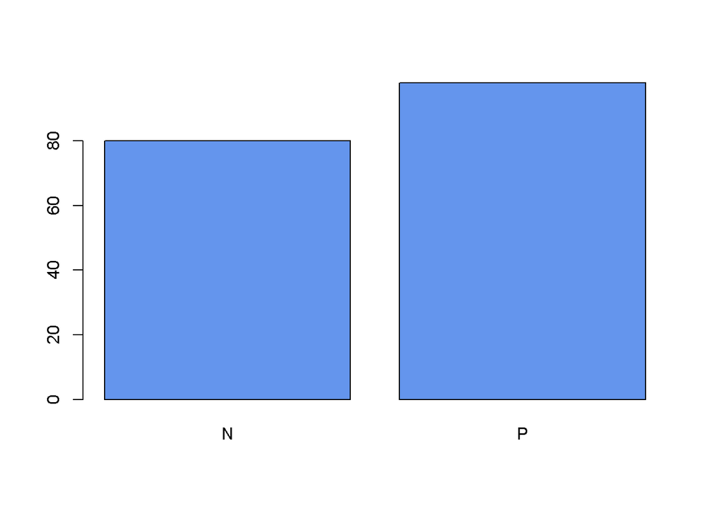

- Gráfica de distribución de clases de la variable prihc

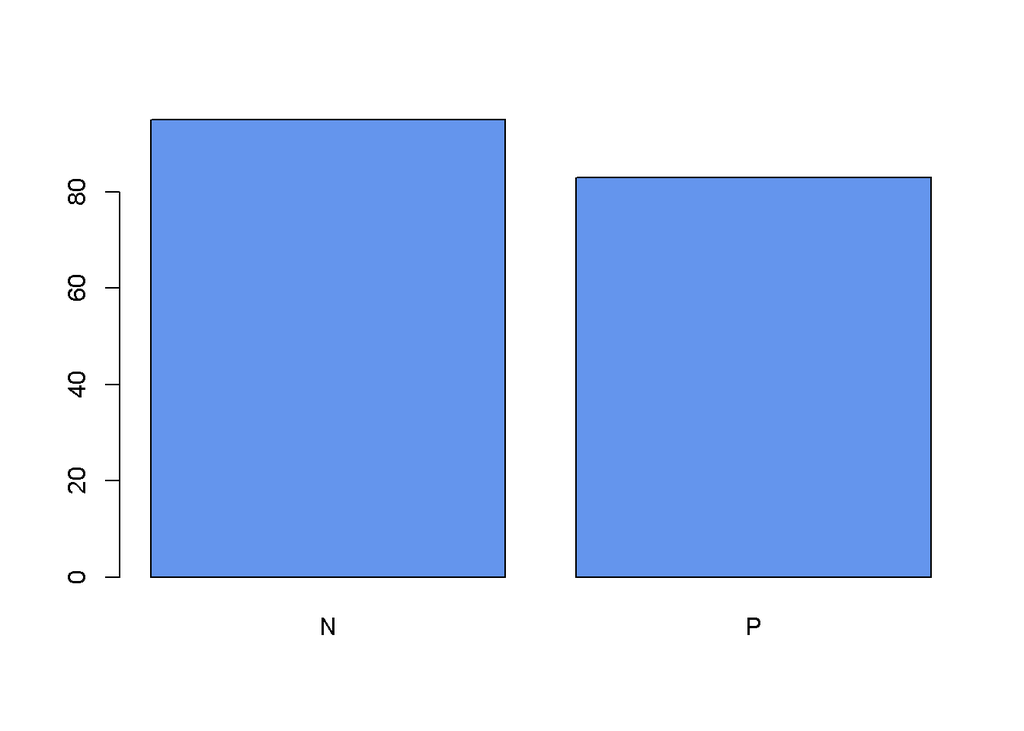

- Gráfica de distribución de clases de la variable her2

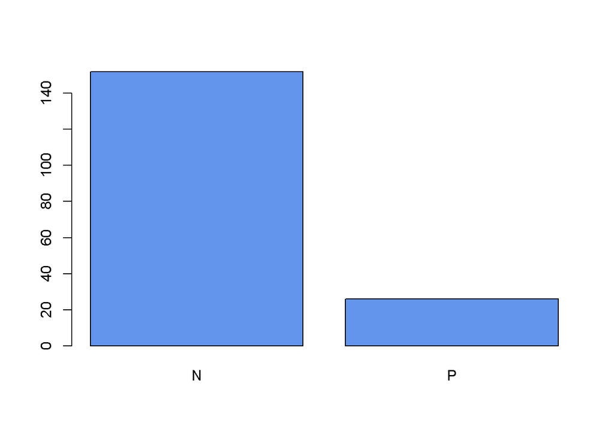

- Gráfica de distribución de clases de la variable tstage

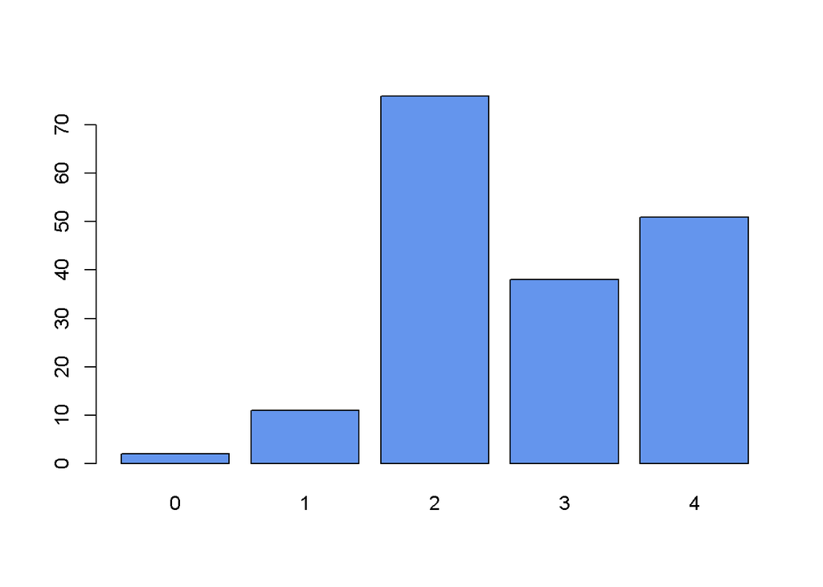

- Gráfica de distribución de clases de la variable nodalstatus

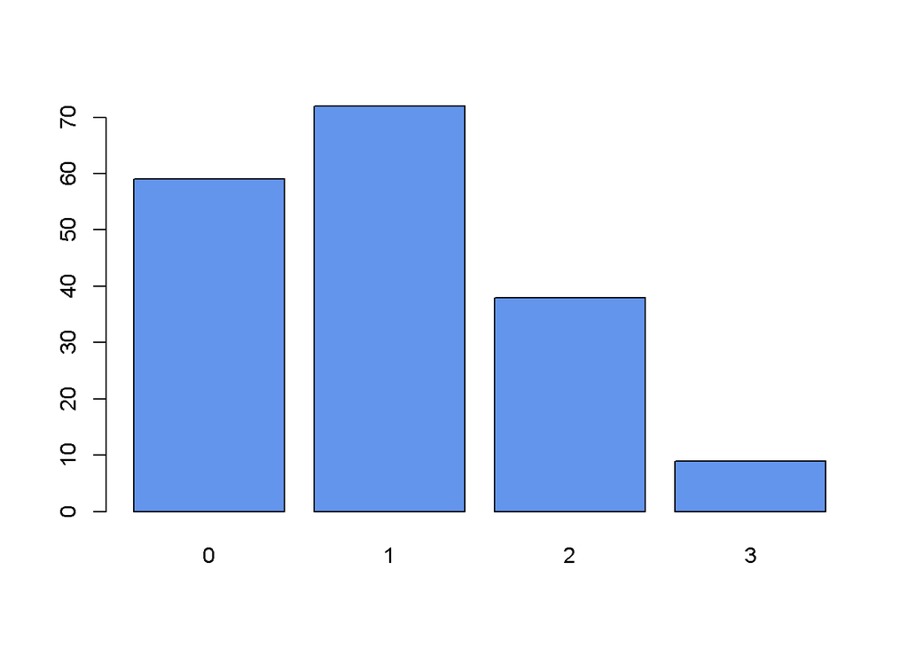

- Gráfica de distribución de clases de la variable grade

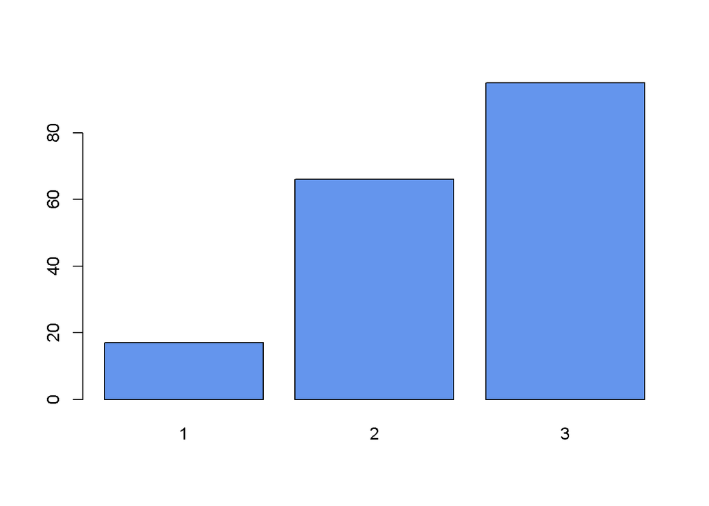

- Gráfica de distribución de clases de la variable pcr

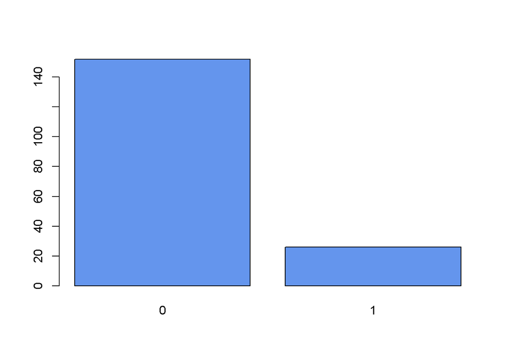

##### **Variables numéricas**

En nuestro caso tenemos como única variable de tipo numérico Edad.

Analizamos los principales parámetros de su distribución

```
##      Media Varianza DesvStand Mediana
## 1 50.91573 113.7386  10.66483      49
```

- Resumen de distribución

```
##    Min. 1st Qu.  Median    Mean 3rd Qu.    Max.
##   26.00   43.25   49.00   50.92   59.00   74.00
```

- Gráfica de distribución de clases de la variable Edad

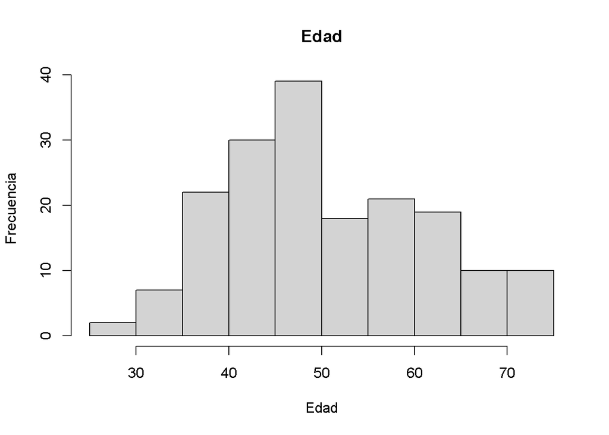

#### Análisis Bivariante

Con el análisis bivariante estudiaremos las relación entre dos variable de nuestro conjunto de datos. Estas podrán ser un par de categóricas, numéricas o ambas.

Con el fin de automatizar el proceso de estudio se ha desarrollado una función llamada BivariateFunction (ACtividad 1).

##### **Variables categóricas**

- Relación PCR vs Edad

Representación gráfica de distribuciones

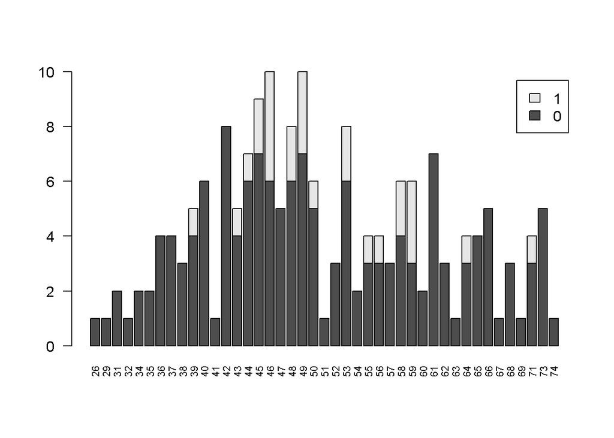

- Análisis PCR vs erihc

Representación gráfica de distribuciones

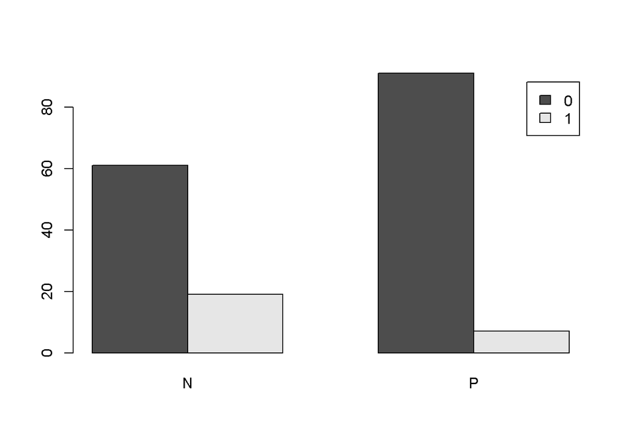

- Análisis PCR vs prihc

Representación gráfica de distribuciones

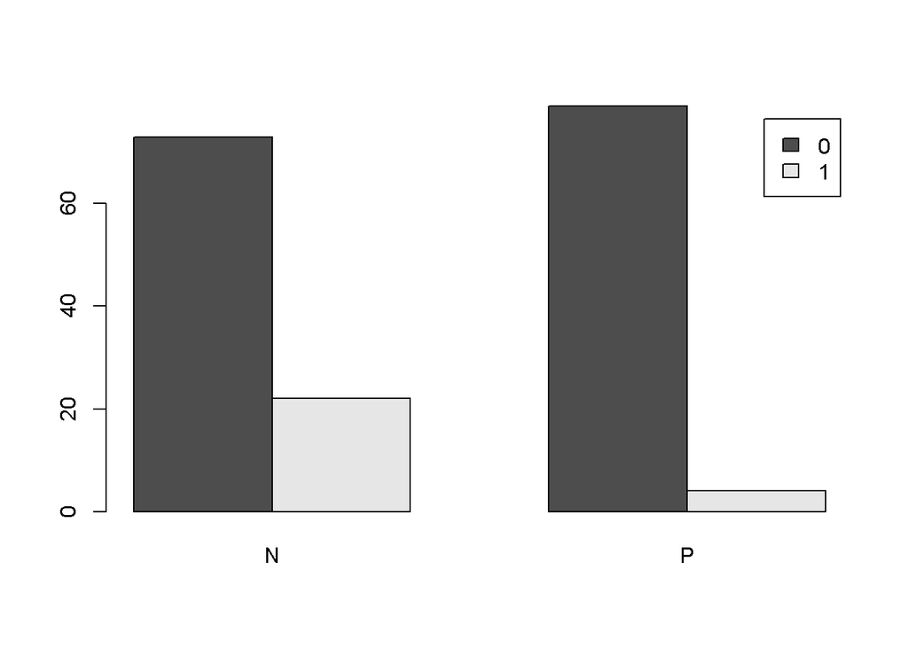

- Análisis PCR vs her2

Representación gráfica de distribuciones

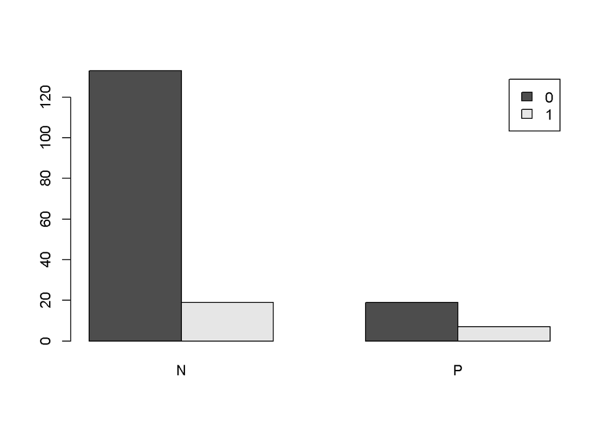

- Análisis PCR vs tstage

Representación gráfica de distribuciones

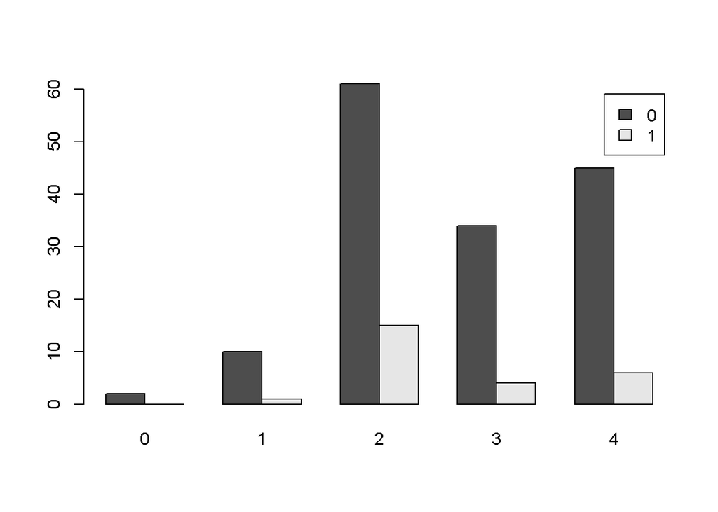

- Análisis PCR vs nodalstatus

Representación gráfica de distribuciones

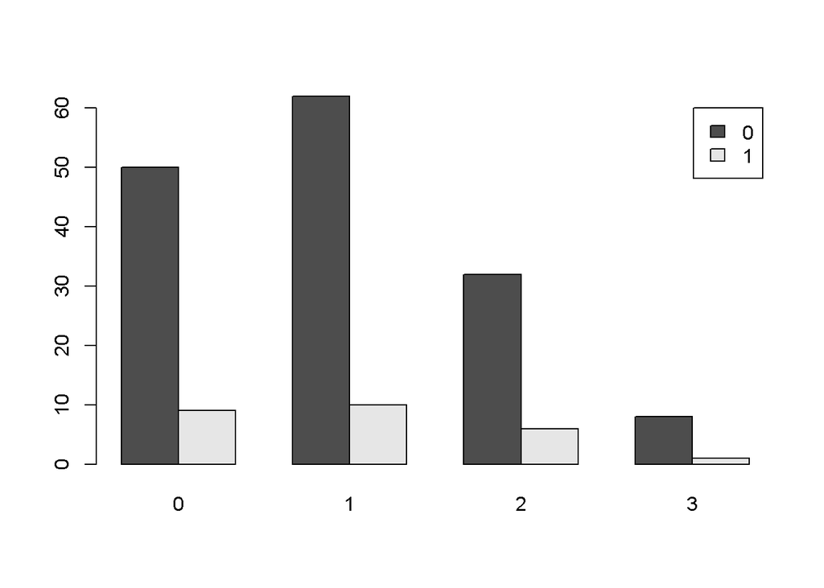

- Análisis PCR vs grade

Representación gráfica de distribuciones

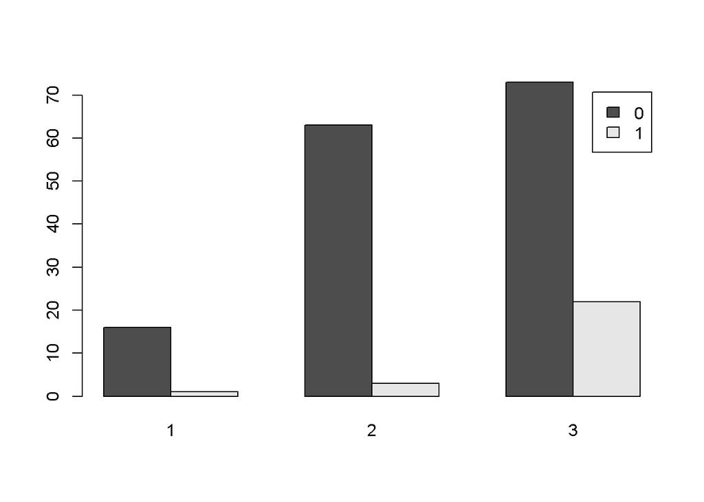

##### **Variable categórica vs numérica**

Analizaremos las distribución de los tres genes más representativos y su relación con pcr.

- Análisis PCR vs AC128677.4…..CH17.132F21.1…..IGKV1OR.1…

Representación gráfica de distribuciones

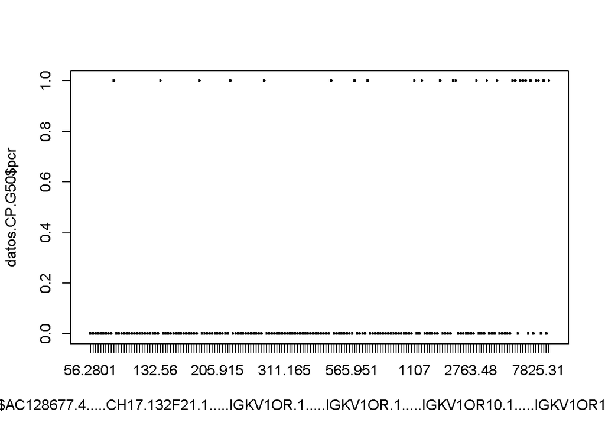

Comprobamos la distribución de los datos de la variable numérica

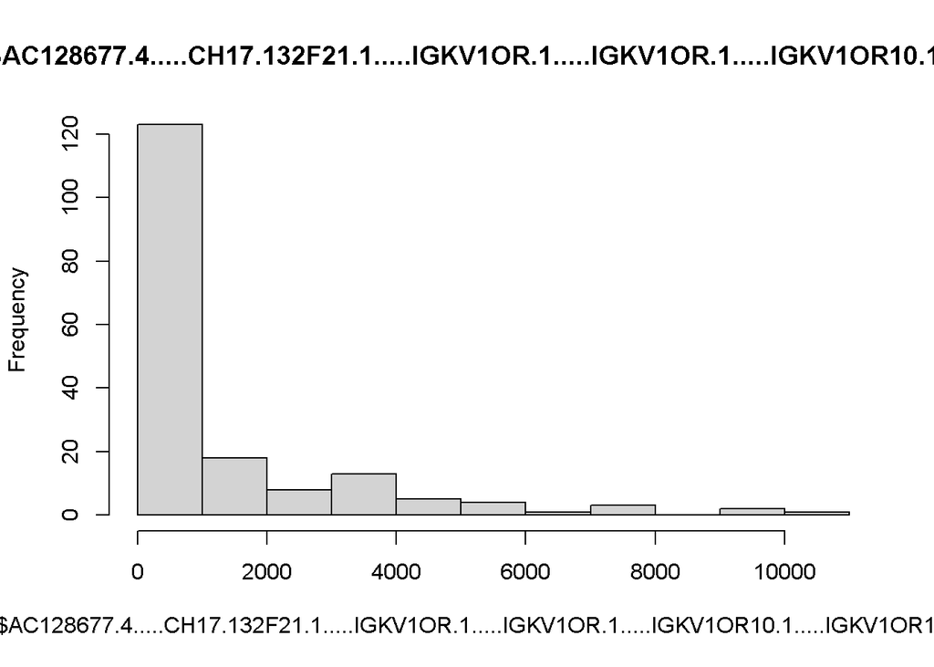

- Análisis PCR vs IGKV1.17…..IGKV1.17

Representación gráfica de distribuciones

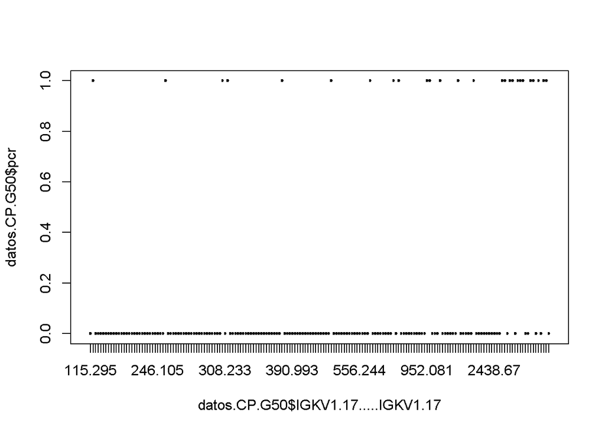

Visualizamos la distribución de los datos de la variable numérica

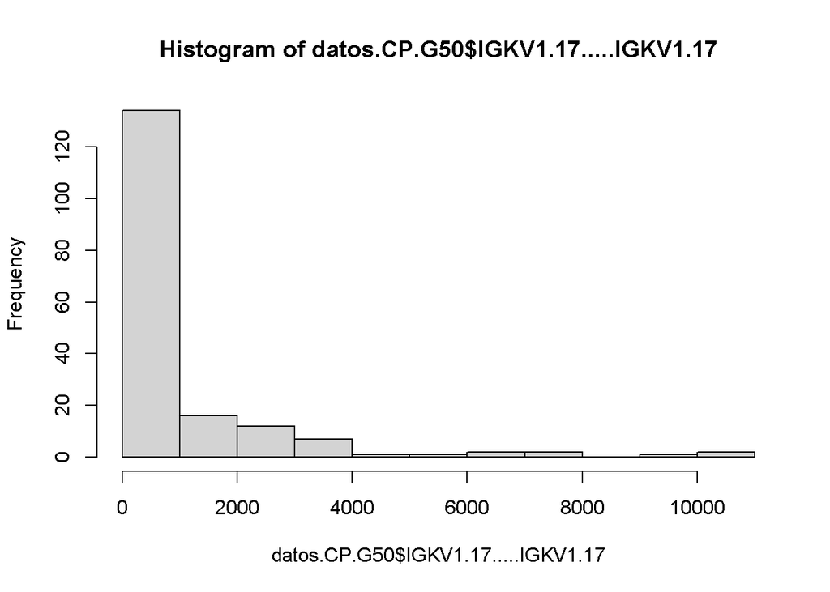

Representación gráfica de distribuciones

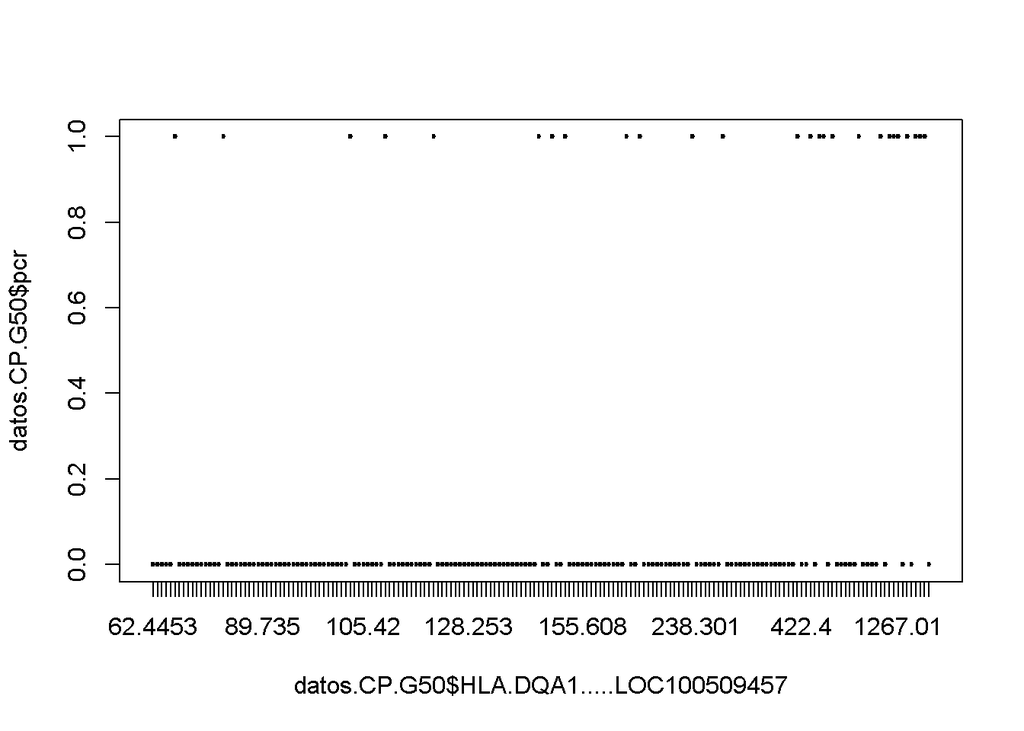

#### Análisis estadístico

- Tests estadísticos

```
##                                                                                                    Columna
## 8                                                                                                      pcr
## 10                                                                                   IGKV1.17.....IGKV1.17
## 9  AC128677.4.....CH17.132F21.1.....IGKV1OR.1.....IGKV1OR.1.....IGKV1OR10.1.....IGKV1OR10.1.....IGKV1OR2.2
## 11                                                                               HLA.DQA1.....LOC100509457
## 3                                                                                                    prihc
## 2                                                                                                    erihc
## 7                                                                                                    grade
## 4                                                                                                     her2
## 5                                                                                                   tstage
## 1                                                                                                      age
## 6                                                                                              nodalstatus
##         p.value
## 8  0.000000e+00
## 10 1.247418e-05
## 9  1.655664e-05
## 11 1.274427e-04
## 3  5.734780e-04
## 2  1.873731e-03
## 7  2.611271e-03
## 4  5.542888e-02
## 5  5.520941e-01
## 1  5.864637e-01
## 6  9.808521e-01
```

- Ganancia de información

```
## Changing dependent variable to factor with levels: FALSE TRUE
```

```
##                                                                                                                                                                                                         Columns
## IGKV1.17.....IGKV1.17                                                                                                                                                                     IGKV1.17.....IGKV1.17
## AC128677.4.....CH17.132F21.1.....IGKV1OR.1.....IGKV1OR.1.....IGKV1OR10.1.....IGKV1OR10.1.....IGKV1OR2.2 AC128677.4.....CH17.132F21.1.....IGKV1OR.1.....IGKV1OR.1.....IGKV1OR10.1.....IGKV1OR10.1.....IGKV1OR2.2
## HLA.DQA1.....LOC100509457                                                                                                                                                             HLA.DQA1.....LOC100509457
## grade                                                                                                                                                                                                     grade
## prihc                                                                                                                                                                                                     prihc
## erihc                                                                                                                                                                                                     erihc
## age                                                                                                                                                                                                         age
## tstage                                                                                                                                                                                                   tstage
## her2                                                                                                                                                                                                       her2
## nodalstatus                                                                                                                                                                                         nodalstatus
##                                                                                                                  IG
## IGKV1.17.....IGKV1.17                                                                                   0.114527780
## AC128677.4.....CH17.132F21.1.....IGKV1OR.1.....IGKV1OR.1.....IGKV1OR10.1.....IGKV1OR10.1.....IGKV1OR2.2 0.098420472
## HLA.DQA1.....LOC100509457                                                                               0.090065778
## grade                                                                                                   0.053478562
## prihc                                                                                                   0.053274988
## erihc                                                                                                   0.040082701
## age                                                                                                     0.032797479
## tstage                                                                                                  0.013412796
## her2                                                                                                    0.012994467
## nodalstatus                                                                                             0.000754984
```

Tanto el análisis por hipótesis como por ganancia de información muestran que las variables más significativas son los 3 marcadores genéticos. En relación a las variables clínico patológicas existen algunas diferencias aunque de nuevo existe coincidencia en las 3 primeras variables en ambos test.

#### Análisis de modelos

##### **Configuración 1** - Decision trees

- Datos = datos.CP.G50
- Cp = seq(0.1, 0.9, by = 0.1)
- Smote = TRUE
- Variables = 10

```
##   Iteracion Modelo Parametro1 Parametro2             TecnicaFS NColumnas
## 1   Parcial     dt        0.4         NA      HypothesisFilter        10
## 2   Parcial     dt        0.2         NA InformationGainFilter        10
## 3   Parcial     dt        0.2         NA InformationGainFilter        10
## 4   Parcial     dt        0.1         NA InformationGainFilter        10
## 5   Parcial     dt        0.3         NA InformationGainFilter        10
## 6    Global     dt       <NA>       <NA>                  <NA>        10
##   ACC.train  ACC.test Precision.train Precision.test AUC.train  AUC.test
## 1 0.5829960 0.7714286             NaN            NaN 0.5000000 0.5000000
## 2 0.8536585 0.8333333       0.8125000      0.3750000 0.8542453 0.7968750
## 3 0.7479675 0.7222222       0.6742424      0.2857143 0.7562399 0.8437500
## 4 0.8056680 0.8571429       0.8313253      0.6000000 0.7863403 0.7155172
## 5 0.5934959 0.8888889             NaN            NaN 0.5000000 0.5000000
## 6 0.7167572 0.8146032             NaN            NaN 0.6793651 0.6712284
##   RECALL.train RECALL.test  F1.train   F1.test
## 1    0.0000000        0.00 0.0000000 0.0000000
## 2    0.8584906        0.75 0.8560677 0.7894737
## 3    0.8240741        1.00 0.7841785 0.8387097
## 4    0.6699029        0.50 0.7315397 0.6315789
## 5    0.0000000        0.00 0.0000000 0.0000000
## 6    0.4704935        0.45 0.4743572 0.4519525
```

##### **Configuración 2** - Decision trees

- Datos = datos.CP.G50
- Cp = seq(0.1, 0.9, by = 0.1)
- Smote = FALSE
- Variables = 6

```
##   Iteracion Modelo Parametro1 Parametro2             TecnicaFS NColumnas
## 1   Parcial     dt        0.1         NA      HypothesisFilter         6
## 2   Parcial     dt        0.1         NA      HypothesisFilter         6
## 3   Parcial     dt        0.1         NA      HypothesisFilter         6
## 4   Parcial     dt        0.1         NA InformationGainFilter         6
## 5   Parcial     dt        0.1         NA InformationGainFilter         6
## 6    Global     dt       <NA>       <NA>                  <NA>         6
##   ACC.train  ACC.test Precision.train Precision.test AUC.train  AUC.test
## 1 0.9020979 0.8000000       0.6363636          0.625 0.6900093 0.7200855
## 2 0.8661972 0.9444444       0.6666667          0.000 0.7143590 0.4857143
## 3 0.8661972 0.9444444       0.6470588          0.500 0.7037429 0.7352941
## 4 0.8802817 0.8888889       0.6000000          0.750 0.7004098 0.7333333
## 5 0.9090909 0.7714286       0.6923077          0.500 0.7340000 0.5439815
## 6 0.8847730 0.8698413       0.6484794          0.475 0.7085042 0.6436817
##   RECALL.train RECALL.test  F1.train   F1.test
## 1    0.4117647   0.5555556 0.5654352 0.6557377
## 2    0.4800000   0.0000000 0.6177024 0.0000000
## 3    0.4583333   0.5000000 0.5994683 0.6538462
## 4    0.4500000   0.5000000 0.5955532 0.6400000
## 5    0.5000000   0.1250000 0.6451613 0.2151394
## 6    0.4600196   0.3361111 0.6046641 0.4329447
```

##### **Configuración 3** - Decision trees

- Datos = datos.CP.G50
- Cp = seq(0.1, 0.9, by = 0.1)
- Smote = FALSE
- Variables = 10

```
##   Iteracion Modelo Parametro1 Parametro2             TecnicaFS NColumnas
## 1   Parcial     dt        0.1         NA InformationGainFilter        10
## 2   Parcial     dt        0.1         NA      HypothesisFilter        10
## 3   Parcial     dt        0.1         NA      HypothesisFilter        10
## 4   Parcial     dt        0.1         NA InformationGainFilter        10
## 5   Parcial     dt        0.1         NA      HypothesisFilter        10
## 6    Global     dt       <NA>       <NA>                  <NA>        10
##   ACC.train  ACC.test Precision.train Precision.test AUC.train  AUC.test
## 1 0.8943662 0.8333333       0.7500000      0.3333333 0.7018890 0.5677419
## 2 0.9014085 0.8055556       0.6470588      0.5000000 0.7650834 0.5541872
## 3 0.8741259 0.9142857       0.5384615      0.8333333 0.6600170 0.8392857
## 4 0.8671329 0.8571429       0.5294118      0.6000000 0.6924797 0.7155172
## 5 0.8802817 0.8888889       0.7500000      0.0000000 0.7229060 0.4571429
## 6 0.8834630 0.8598413       0.6429864      0.4533333 0.7084750 0.6267750
##   RECALL.train RECALL.test  F1.train   F1.test
## 1    0.4285714   0.2000000 0.5794677 0.3225806
## 2    0.5789474   0.1428571 0.7050576 0.2426778
## 3    0.3684211   0.7142857 0.5183649 0.8020050
## 4    0.4500000   0.5000000 0.5925139 0.6315789
## 5    0.4800000   0.0000000 0.6212466 0.0000000
## 6    0.4611880   0.3114286 0.6033302 0.3997685
```

##### **Configuración 4** - Decision trees

- Datos = datos.CP.G50
- Cp = seq(0.1, 0.9, by = 0.1)
- Smote = TRUE
- Variables = 10
- One Hot Encoding
- Datos normalizados

```
##   Iteracion Modelo Parametro1 Parametro2             TecnicaFS NColumnas
## 1   Parcial     dt        0.1         NA      HypothesisFilter        10
## 2   Parcial     dt        0.1         NA InformationGainFilter        10
## 3   Parcial     dt        0.1         NA      HypothesisFilter        10
## 4   Parcial     dt        0.3         NA InformationGainFilter        10
## 5   Parcial     dt        0.3         NA InformationGainFilter        10
## 6    Global     dt       <NA>       <NA>                  <NA>        10
##   ACC.train  ACC.test Precision.train Precision.test AUC.train  AUC.test
## 1 0.7439024 0.8333333       0.8771930            0.6 0.7108491 0.6798030
## 2 0.8455285 0.7777778       0.7946429            0.5 0.8468987 0.7232143
## 3 0.7327935 0.9428571       0.9130435            1.0 0.6879371 0.6666667
## 4 0.5731707 0.8333333             NaN            NaN 0.5000000 0.5000000
## 5 0.5910931 0.9428571             NaN            NaN 0.5000000 0.5000000
## 6 0.6972977 0.8660317             NaN            NaN 0.6491370 0.6139368
##   RECALL.train RECALL.test  F1.train   F1.test
## 1    0.4716981   0.4285714 0.5773235 0.5660377
## 2    0.8557692   0.6250000 0.8506180 0.6930693
## 3    0.4038462   0.3333333 0.5207206 0.4925373
## 4    0.0000000   0.0000000 0.0000000 0.0000000
## 5    0.0000000   0.0000000 0.0000000 0.0000000
## 6    0.3462627   0.2773810 0.3897324 0.3503289
```

**Resultados Globales Decision Tree**

```
##    Iteracion Modelo Parametro1 Parametro2 TecnicaFS NColumnas ACC.train
## 6     Global     dt       <NA>       <NA>      <NA>        10 0.7167572
## 12    Global     dt       <NA>       <NA>      <NA>         6 0.8847730
## 18    Global     dt       <NA>       <NA>      <NA>        10 0.8834630
## 24    Global     dt       <NA>       <NA>      <NA>        10 0.6972977
##     ACC.test Precision.train Precision.test AUC.train  AUC.test RECALL.train
## 6  0.8146032             NaN            NaN 0.6793651 0.6712284    0.4704935
## 12 0.8698413       0.6484794      0.4750000 0.7085042 0.6436817    0.4600196
## 18 0.8598413       0.6429864      0.4533333 0.7084750 0.6267750    0.4611880
## 24 0.8660317             NaN            NaN 0.6491370 0.6139368    0.3462627
##    RECALL.test  F1.train   F1.test Configuracion
## 6    0.4500000 0.4743572 0.4519525             1
## 12   0.3361111 0.6046641 0.4329447             2
## 18   0.3114286 0.6033302 0.3997685             3
## 24   0.2773810 0.3897324 0.3503289             4
```

##### **Configuración 1** - Neural Networks

- Datos = datos.CP.G50
- Neuronas = seq(1, 100, by = 20)
- Decay = seq(0.01, 0.3, by = 0.05)
- Smote = TRUE
- Variables = 10

```
##   Iteracion Modelo Parametro1 Parametro2             TecnicaFS NColumnas
## 1   Parcial   nnet         41       0.16 InformationGainFilter        10
## 2   Parcial   nnet         21       0.26 InformationGainFilter        10
## 3   Parcial   nnet         61       0.11      HypothesisFilter        10
## 4   Parcial   nnet         41       0.11 InformationGainFilter        10
## 5   Parcial   nnet         61       0.26 InformationGainFilter        10
## 6    Global   nnet       <NA>       <NA>                  <NA>        10
##   ACC.train  ACC.test Precision.train Precision.test AUC.train  AUC.test
## 1 0.7073171 0.7222222       0.7162162      0.3333333 0.6808640 0.7000000
## 2 0.7044534 0.9142857       0.8076923      0.5000000 0.6647887 0.6510417
## 3 0.8008130 0.8611111       0.8000000      0.5000000 0.7865775 0.8354839
## 4 0.7570850 0.7428571       0.7948718      0.3333333 0.7357152 0.5714286
## 5 0.7764228 0.8055556       0.7582418      0.4000000 0.7618464 0.8032258
## 6 0.7492183 0.8092063       0.7754044      0.4133333 0.7259584 0.7122360
##   RECALL.train RECALL.test  F1.train   F1.test
## 1    0.5096154   0.6666667 0.5924070 0.6933333
## 2    0.4000000   0.3333333 0.5102639 0.4885496
## 3    0.6990291   0.8000000 0.7464674 0.8294314
## 4    0.5849057   0.2857143 0.6599499 0.4126984
## 5    0.6764706   0.8000000 0.7230086 0.8027682
## 6    0.5740042   0.5771429 0.6464194 0.6453562
```

##### **Configuración 2** - Neural Networks

- Datos = datos.CP.G50
- Neuronas = seq(1, 100, by = 20)
- Decay = seq(0.01, 0.3, by = 0.05)
- Smote = FALSE
- Variables = 10

```
##   Iteracion Modelo Parametro1 Parametro2             TecnicaFS NColumnas
## 1   Parcial   nnet         81       0.06 InformationGainFilter        10
## 2   Parcial   nnet         41       0.06 InformationGainFilter        10
## 3   Parcial   nnet         21       0.06 InformationGainFilter        10
## 4   Parcial   nnet         21       0.11      HypothesisFilter        10
## 5   Parcial   nnet         21       0.01      HypothesisFilter        10
## 6    Global   nnet       <NA>       <NA>                  <NA>        10
##   ACC.train  ACC.test Precision.train Precision.test AUC.train  AUC.test
## 1 0.9154930 0.7777778       0.9000000           0.25 0.7209016 0.5333333
## 2 0.9020979 0.8571429       1.0000000            NaN 0.6666667 0.5000000
## 3 0.8741259 0.8857143       0.8571429           0.00 0.6262681 0.4843750
## 4 0.9366197 0.8055556       0.8235294           0.40 0.8377049 0.6166667
## 5 0.8661972 0.8055556       1.0000000           0.00 0.5250000 0.4833333
## 6 0.8989067 0.8263492       0.9161345            NaN 0.6753083 0.5235417
##   RECALL.train RECALL.test   F1.train   F1.test
## 1    0.4500000   0.1666667 0.60340382 0.2745098
## 2    0.3333333   0.0000000 0.48679245 0.0000000
## 3    0.2608696   0.0000000 0.40182159 0.0000000
## 4    0.7000000   0.3333333 0.80120482 0.4715447
## 5    0.0500000   0.0000000 0.09454266 0.0000000
## 6    0.3588406   0.1000000 0.47755307 0.1492109
```

##### **Configuración 3** - Neural Networks

- Datos = datos.CP.G50
- Neuronas = seq(1, 100, by = 20)
- Decay = seq(0.01, 0.3, by = 0.05)
- Smote = FALSE
- Variables = 6

```
##   Iteracion Modelo Parametro1 Parametro2             TecnicaFS NColumnas
## 1   Parcial   nnet         21       0.01      HypothesisFilter         6
## 2   Parcial   nnet         41       0.06 InformationGainFilter         6
## 3   Parcial   nnet         61       0.06      HypothesisFilter         6
## 4   Parcial   nnet         41       0.06      HypothesisFilter         6
## 5   Parcial   nnet         41       0.11 InformationGainFilter         6
## 6    Global   nnet       <NA>       <NA>                  <NA>         6
##   ACC.train  ACC.test Precision.train Precision.test AUC.train  AUC.test
## 1 0.8951049 0.7428571       0.6111111      0.2500000 0.7612479 0.5178571
## 2 0.8732394 0.9444444       0.7777778      1.0000000 0.6437706 0.6666667
## 3 0.9084507 0.7500000       1.0000000            NaN 0.6176471 0.5000000
## 4 0.8943662 0.9444444       0.8571429      0.0000000 0.7314530 0.4857143
## 5 0.9230769 0.8571429       0.9090909      0.6666667 0.7459350 0.6494253
## 6 0.8988476 0.8477778       0.8310245            NaN 0.7000107 0.5639327
##   RECALL.train RECALL.test  F1.train   F1.test
## 1    0.5789474   0.1428571 0.7031211 0.2396313
## 2    0.3043478   0.3333333 0.4513781 0.4927536
## 3    0.2352941   0.0000000 0.3737776 0.0000000
## 4    0.4800000   0.0000000 0.6247182 0.0000000
## 5    0.5000000   0.3333333 0.6486486 0.4800000
## 6    0.4197179   0.1619048 0.5603287 0.2424770
```

##### **Configuración 4** - Neural Networks

- Datos = datos.CP.G50
- Neuronas = seq(1, 100, by = 20)
- Decay = seq(0.01, 0.3, by = 0.05)
- Smote = tRUE
- Variables = 10
- One Hot Endoding
- Datos normalizados

```
##   Iteracion Modelo Parametro1 Parametro2             TecnicaFS NColumnas
## 1   Parcial   nnet         21       0.11      HypothesisFilter        10
## 2   Parcial   nnet         41       0.11      HypothesisFilter        10
## 3   Parcial   nnet         21       0.06 InformationGainFilter        10
## 4   Parcial   nnet          1       0.16      HypothesisFilter        10
## 5   Parcial   nnet          1       0.16 InformationGainFilter        10
## 6    Global   nnet       <NA>       <NA>                  <NA>        10
##   ACC.train  ACC.test Precision.train Precision.test AUC.train  AUC.test
## 1 0.9268293 0.8888889       0.9215686      0.7777778 0.9237541 0.8518519
## 2 0.9186992 0.8611111       0.8899083      0.5000000 0.9193516 0.8354839
## 3 0.9635628 0.9714286       0.9595960      0.8333333 0.9613946 0.9833333
## 4 0.7732794 0.8000000       0.6991870      0.3636364 0.7792421 0.8870968
## 5 0.8252033 0.9166667       0.7787611      0.5000000 0.8258086 0.9545455
## 6 0.8815148 0.8876190       0.8498042      0.5949495 0.8819102 0.9024623
##   RECALL.train RECALL.test  F1.train   F1.test
## 1    0.9038462   0.7777778 0.9151934 0.8296296
## 2    0.9238095   0.8000000 0.9212473 0.8294314
## 3    0.9500000   1.0000000 0.9567333 0.9855072
## 4    0.8190476   1.0000000 0.7955057 0.8888889
## 5    0.8301887   1.0000000 0.8276885 0.9565217
## 6    0.8853784   0.9155556 0.8832736 0.8979958
```

**Resultados Globales Neural Network**

[output not shown]

##### **Configuración 1** - Support Vector Machine

- Datos = datos.CP.G50
- Gamma = seq(1, 80, by = 15)
- Cost = seq(1, 100, by = 20)
- Smote = TRUE
- Variables = 10

```
##   Iteracion Modelo Parametro1 Parametro2             TecnicaFS NColumnas
## 1   Parcial    svm          1          1      HypothesisFilter        10
## 2   Parcial    svm          1         61      HypothesisFilter        10
## 3   Parcial    svm          1         81      HypothesisFilter        10
## 4   Parcial    svm         16         41 InformationGainFilter        10
## 5   Parcial    svm          1         61      HypothesisFilter        10
## 6    Global    svm       <NA>       <NA>                  <NA>        10
##   ACC.train  ACC.test Precision.train Precision.test AUC.train  AUC.test
## 1 0.8943089 0.9166667       0.8686869      0.7500000 0.8901257 0.8940887
## 2 0.9878049 0.9722222       0.9724771      0.8571429 0.9892857 0.9833333
## 3 0.9878543 0.9714286       0.9813084      0.8000000 0.9881908 0.9838710
## 4 1.0000000 0.9428571       1.0000000      1.0000000 1.0000000 0.8000000
## 5 0.9796748 1.0000000       1.0000000      1.0000000 0.9764151 1.0000000
## 6 0.9699286 0.9606349       0.9644945      0.8814286 0.9688035 0.9322586
##   RECALL.train RECALL.test  F1.train   F1.test
## 1    0.8686869   0.8571429 0.8813117 0.8859060
## 2    1.0000000   1.0000000 0.9938650 0.9859155
## 3    0.9905660   1.0000000 0.9892083 0.9855072
## 4    1.0000000   0.6000000 1.0000000 0.7333333
## 5    0.9528302   1.0000000 0.9660660 1.0000000
## 6    0.9624166   0.8914286 0.9660902 0.9181324
```

##### **Configuración 2** - Support Vector Machine

- Datos = datos.CP.G50
- Gamma = seq(1, 80, by = 15)
- Cost = seq(1, 100, by = 20)
- Smote = FALSE
- Variables = 10

```
##   Iteracion Modelo Parametro1 Parametro2             TecnicaFS NColumnas
## 1   Parcial    svm          1          1      HypothesisFilter        10
## 2   Parcial    svm         16          1      HypothesisFilter        10
## 3   Parcial    svm          1         61      HypothesisFilter        10
## 4   Parcial    svm          1         21 InformationGainFilter        10
## 5   Parcial    svm          1          1      HypothesisFilter        10
## 6    Global    svm       <NA>       <NA>                  <NA>        10
##   ACC.train  ACC.test Precision.train Precision.test AUC.train  AUC.test
## 1 0.9440559 0.8285714               1              0 0.8095238 0.4833333
## 2 0.9929577 0.7777778               1            NaN 0.9722222 0.5000000
## 3 0.8521127 0.8333333             NaN              0 0.5000000 0.4838710
## 4 0.8391608 0.9142857             NaN            NaN 0.5000000 0.5000000
## 5 0.9577465 0.8611111               1            NaN 0.8571429 0.5000000
## 6 0.9172067 0.8430159             NaN            NaN 0.7277778 0.4934409
##   RECALL.train RECALL.test  F1.train F1.test
## 1    0.6190476           0 0.7477631       0
## 2    0.9444444           0 0.9680937       0
## 3    0.0000000           0 0.0000000       0
## 4    0.0000000           0 0.0000000       0
## 5    0.7142857           0 0.8182912       0
## 6    0.4555556           0 0.5068296       0
```

##### **Configuración 3** - Support Vector Machine

- Datos = datos.CP.G50
- Gamma = seq(1, 80, by = 15)
- Cost = seq(1, 100, by = 20)
- Smote = FALSE
- Variables = 6

```
##   Iteracion Modelo Parametro1 Parametro2             TecnicaFS NColumnas
## 1   Parcial    svm          1          1      HypothesisFilter         6
## 2   Parcial    svm          1          1 InformationGainFilter         6
## 3   Parcial    svm          1          1      HypothesisFilter         6
## 4   Parcial    svm         31          1      HypothesisFilter         6
## 5   Parcial    svm          1          1 InformationGainFilter         6
## 6    Global    svm       <NA>       <NA>                  <NA>         6
##   ACC.train  ACC.test Precision.train Precision.test AUC.train AUC.test
## 1 0.8671329 0.8000000             NaN            NaN 0.5000000 0.500000
## 2 0.9510490 0.8000000               1            NaN 0.8157895 0.500000
## 3 0.8943662 0.8333333               1            NaN 0.6250000 0.500000
## 4 0.9577465 0.9444444               1            NaN 0.8750000 0.500000
## 5 0.9366197 0.8333333               1           0.25 0.7954545 0.578125
## 6 0.9213828 0.8422222             NaN            NaN 0.7222488 0.515625
##   RECALL.train RECALL.test  F1.train    F1.test
## 1    0.0000000        0.00 0.0000000 0.00000000
## 2    0.6315789        0.00 0.7590698 0.00000000
## 3    0.2500000        0.00 0.3907692 0.00000000
## 4    0.7500000        0.00 0.8412371 0.00000000
## 5    0.5909091        0.25 0.7246438 0.38461538
## 6    0.4444976        0.05 0.5431440 0.07692308
```

##### **Configuración 4** - Support Vector Machine

- Datos = datos.CP.G50
- Gamma = seq(1, 80, by = 15)
- Cost = seq(1, 100, by = 20)
- Smote = TRUE
- Variables = 10
- One Hot Encoding
- Datos Normalizados

```
##   Iteracion Modelo Parametro1 Parametro2             TecnicaFS NColumnas
## 1   Parcial    svm          1          1      HypothesisFilter        10
## 2   Parcial    svm          1         21 InformationGainFilter        10
## 3   Parcial    svm         16          1      HypothesisFilter        10
## 4   Parcial    svm          1         41 InformationGainFilter        10
## 5   Parcial    svm          1          1 InformationGainFilter        10
## 6    Global    svm       <NA>       <NA>                  <NA>        10
##   ACC.train  ACC.test Precision.train Precision.test AUC.train  AUC.test
## 1 0.8861789 0.9444444       0.8979592      0.8333333 0.8793801 0.9000000
## 2 1.0000000 1.0000000       1.0000000      1.0000000 1.0000000 1.0000000
## 3 0.9918699 0.9722222       0.9805825      0.8333333 0.9931034 0.9838710
## 4 1.0000000 1.0000000       1.0000000      1.0000000 1.0000000 1.0000000
## 5 0.9268293 0.8888889       0.9569892      0.5000000 0.9180528 0.8281250
## 6 0.9609756 0.9611111       0.9671062      0.8333333 0.9581073 0.9423992
##   RECALL.train RECALL.test  F1.train   F1.test
## 1    0.8301887   0.8333333 0.8572705 0.8854167
## 2    1.0000000   1.0000000 1.0000000 1.0000000
## 3    1.0000000   1.0000000 0.9959184 0.9859155
## 4    1.0000000   1.0000000 1.0000000 1.0000000
## 5    0.8640777   0.7500000 0.8943541 0.8135593
## 6    0.9388533   0.9166667 0.9495086 0.9369783
```

**Resultados Globales Support Vector Machine**

[output not shown]

##### **Configuración 1** - Logistic Regression

- Datos = datos.CP.G50
- Smote = TRUE
- Variables = 10

```
##   Iteracion Modelo Parametro1 Parametro2        TecnicaFS NColumnas ACC.train
## 1   Parcial     rl         NA         NA HypothesisFilter        10 0.7642276
## 2   Parcial     rl         NA         NA HypothesisFilter        10 0.7642276
## 3   Parcial     rl         NA         NA HypothesisFilter        10 0.7845528
## 4   Parcial     rl         NA         NA HypothesisFilter        10 0.7489879
## 5   Parcial     rl         NA         NA HypothesisFilter        10 0.7854251
## 6    Global     rl       <NA>       <NA>             <NA>        10 0.7694842
##    ACC.test Precision.train Precision.test AUC.train  AUC.test RECALL.train
## 1 0.8055556       0.7692308      0.2857143 0.7515632 0.6718750    0.6542056
## 2 0.8888889       0.7721519      0.6666667 0.7399112 0.8000000    0.6039604
## 3 0.8055556       0.7931034      0.4285714 0.7683505 0.6833333    0.6634615
## 4 0.7428571       0.7590361      0.3000000 0.7295775 0.6833333    0.6000000
## 5 0.8857143       0.7976190      0.5714286 0.7662149 0.8500000    0.6504854
## 6 0.8257143       0.7782283      0.4504762 0.7511235 0.7377083    0.6344226
##   RECALL.test  F1.train   F1.test
## 1   0.5000000 0.7049496 0.6170213
## 2   0.6666667 0.6747073 0.7619048
## 3   0.5000000 0.7189440 0.6170213
## 4   0.6000000 0.6662665 0.6638298
## 5   0.8000000 0.7116148 0.8406780
## 6   0.6133333 0.6952965 0.7000910
```

##### **Configuración 2** - Logistic Regression

- Datos = datos.CP.G50
- Smote = FALSE
- Variables = 10

```
##   Iteracion Modelo Parametro1 Parametro2             TecnicaFS NColumnas
## 1   Parcial     rl         NA         NA      HypothesisFilter        10
## 2   Parcial     rl         NA         NA      HypothesisFilter        10
## 3   Parcial     rl         NA         NA      HypothesisFilter        10
## 4   Parcial     rl         NA         NA InformationGainFilter        10
## 5   Parcial     rl         NA         NA InformationGainFilter        10
## 6    Global     rl       <NA>       <NA>                  <NA>        10
##   ACC.train  ACC.test Precision.train Precision.test AUC.train  AUC.test
## 1 0.8732394 0.8611111       0.6666667           0.00 0.6651515 0.4843750
## 2 0.9160839 0.8285714       0.9000000           0.50 0.7209350 0.6321839
## 3 0.8802817 0.8611111       0.7142857           1.00 0.6168033 0.5833333
## 4 0.8591549 0.8333333       0.6250000           0.25 0.6011364 0.5781250
## 5 0.8671329 0.8000000       0.5714286           0.00 0.5878049 0.4827586
## 6 0.8791786 0.8368254       0.6954762           0.35 0.6383662 0.5521552
##   RECALL.train RECALL.test  F1.train   F1.test
## 1    0.3636364   0.0000000 0.5134576 0.0000000
## 2    0.4500000   0.3333333 0.6035321 0.4754098
## 3    0.2500000   0.1666667 0.3894081 0.2792793
## 4    0.2272727   0.2500000 0.3594579 0.3846154
## 5    0.2000000   0.0000000 0.3250328 0.0000000
## 6    0.2981818   0.1500000 0.4381777 0.2278609
```

##### **Configuración 3** - Logistic Regression

- Datos = datos.CP.G50
- Smote = FALSE
- Variables = 6

```
##   Iteracion Modelo Parametro1 Parametro2             TecnicaFS NColumnas
## 1   Parcial     rl         NA         NA InformationGainFilter         6
## 2   Parcial     rl         NA         NA InformationGainFilter         6
## 3   Parcial     rl         NA         NA InformationGainFilter         6
## 4   Parcial     rl         NA         NA      HypothesisFilter         6
## 5   Parcial     rl         NA         NA      HypothesisFilter         6
## 6    Global     rl       <NA>       <NA>                  <NA>         6
##   ACC.train  ACC.test Precision.train Precision.test AUC.train  AUC.test
## 1 0.8601399 0.8857143       0.6666667      0.3333333 0.6179348 0.6354167
## 2 0.8521127 0.9444444       0.6666667            NaN 0.6122881 0.5000000
## 3 0.9014085 0.7500000       0.8750000      0.0000000 0.6709016 0.4500000
## 4 0.8943662 0.7777778       0.6666667      1.0000000 0.6096471 0.5555556
## 5 0.8741259 0.8571429       0.7500000      1.0000000 0.5709350 0.5833333
## 6 0.8764306 0.8430159       0.7250000            NaN 0.6163413 0.5448611
##   RECALL.train RECALL.test  F1.train   F1.test
## 1    0.2608696   0.3333333 0.4003255 0.4843750
## 2    0.2500000   0.0000000 0.3865815 0.0000000
## 3    0.3500000   0.0000000 0.5042206 0.0000000
## 4    0.2352941   0.1111111 0.3725706 0.1944444
## 5    0.1500000   0.1666667 0.2560601 0.2790698
## 6    0.2492327   0.1222222 0.3839516 0.1915778
```

##### **Configuración 4** - Logistic Regression

- Datos = datos.CP.G50
- Smote = TRUE
- Variables = 10
- One Hot Encoding
- Normalizados

```
##   Iteracion Modelo Parametro1 Parametro2             TecnicaFS NColumnas
## 1   Parcial     rl         NA         NA      HypothesisFilter        10
## 2   Parcial     rl         NA         NA InformationGainFilter        10
## 3   Parcial     rl         NA         NA InformationGainFilter        10
## 4   Parcial     rl         NA         NA      HypothesisFilter        10
## 5   Parcial     rl         NA         NA      HypothesisFilter        10
## 6    Global     rl       <NA>       <NA>                  <NA>        10
##   ACC.train  ACC.test Precision.train Precision.test AUC.train  AUC.test
## 1 0.7732794 0.8857143       0.7951807      0.7142857 0.7544266 0.8214286
## 2 0.7682927 0.7777778       0.7804878      0.1428571 0.7477425 0.5757576
## 3 0.7651822 0.8285714       0.7441860      0.3333333 0.7451701 0.6854839
## 4 0.7886179 0.8888889       0.7956989      0.6363636 0.7774491 0.9310345
## 5 0.7804878 0.7500000       0.7865169      0.2500000 0.7659574 0.6032258
## 6 0.7751720 0.8261905       0.7804141      0.4153680 0.7581491 0.7233861
##   RECALL.train RECALL.test  F1.train   F1.test
## 1    0.6285714   0.7142857 0.6934566 0.7908163
## 2    0.6213592   0.3333333 0.6870580 0.4666667
## 3    0.6400000   0.5000000 0.6970151 0.6236559
## 4    0.6915888   1.0000000 0.7369232 0.9411765
## 5    0.6666667   0.4000000 0.7191011 0.5217391
## 6    0.6496372   0.5895238 0.7067108 0.6688109
```

**Resultados Globales Logistic Regression**

[output not shown]

**Mejores resultados Globales**

[output not shown]

## Conclusiones

En este trabajo hemos propuesto, un conjunto de modelos de aprendizaje computacional, aplicados a la predicción de respuesta de un tratamiento quimioterapéutico en cancer de mama.

Con el fin de poder tener un mayor conocimiento sobre la influencia de un conjunto de genes marcadores en la respuesta del tratamiento, como también en poder reducir el coste computacional del problema hemos aplicado técnicas de selección de variables de tipo filtrado.

Teniendo en cuenta el problema de desbalanceo de clases del conjunto de datos se ha aplicado la técnica de sobremuestreo sintético SMOTE.

Se ha alcanzado un rendimiento aceptable con algunos de los algoritmos aplicados, destancando SVM y Neural Networks.

Entre las líneas de mejora futura destacamos, la optimización de la solución aplicada al problema de desbalanceo de clases y la aplicación de métodos de selección de variables que permitan hacer una elección basada en características propias de los genes y su expresión.